# Sequence Search Analysis Writeup (E2 & combined analysis)

Mona Zhu

Updated June 19, 2019

```r
knitr::opts_chunk$set(warning=TRUE, message = FALSE)
```

```r
# load libraries
# tidying data
library(reshape2)
library(sjPlot)

# plotting
library(ggplot2)
library(car)
library(plyr)
library(wesanderson)

# analyses
library(lme4)
library(ez)
```

```r
# Importing data
# setwd("C:/Users/Grayden Solman/Desktop/Mona/Sequenced Search")
setwd("C:/Users/MonaZhu/Dropbox/Grayden/Sequenced Search")
# setwd("//fileu/users$/jhzhu/Desktop/Sequenced Search")
raw1a<-read.table("summary_firstHalf.txt", sep="\t", header=T)
raw1a$Experiment<-"E1a"
raw1b<-read.table("summary_secondHalf.txt", sep="\t", header=T)
raw1b$Experiment<-"E1b"
raw2<-read.table("summary.txt", sep="\t", header=T)
raw2$Experiment<-"E2"

df<-rbind(raw1a, raw1b, raw2)

# Item Level Data
rawi1a<-read.table("summaryByItems_firstHalf.txt", sep="\t", header=T)
rawi1a$Experiment<-"E1a"
rawi1b<-read.table("summaryByItems_secondHalf.txt", sep="\t", header=T)
rawi1b$Experiment<-"E1b"
rawi2<-read.table("summaryByItems.txt", sep="\t", header=T)
rawi2$Experiment<-"E2"

item<-rbind(rawi1a, rawi1b, rawi2)

# Creating additional variables
df$SUBJECT<-factor(paste0(df$SUBJECT,df$Experiment))
df$Organization<-factor(ifelse(df$NUM_ORG_MOVES==0, "No", "Yes"))
df$Org.Num<-ifelse(df$NUM_ORG_MOVES==0, 0, 1)
df$SeqType<-factor(ifelse(df$SEQ_LEN<5, "Short", "Long"))
df$SeqType<-factor(df$SeqType, levels(df$SeqType)[c(2,1)])
df$PrepTime<-(df$SEARCH_START_TIME-df$TRIAL_START_TIME)/1000
df$SearchTimeTotal<-(df$SEARCH_COMPLETION_TIME-df$SEARCH_START_TIME)/1000
df$SearchTimeAvg<-df$SearchTimeTotal/df$SEQ_LEN
df$Repetition<-df$SEQ_LEN/df$NUM_UNIQUE_IN_SEQ

e1a<-subset(df, Experiment=="E1a")
e1a$uniq.c <- e1a$NUM_UNIQUE_IN_SEQ - mean(e1a$NUM_UNIQUE_IN_SEQ)
e1a$rep.c<-e1a$Repetition - mean(e1a$Repetition)
e1a$trial.c<-e1a$TRIAL - mean(e1a$TRIAL)

e1b<-subset(df, Experiment=="E1b")
e1b$uniq.c <- e1b$NUM_UNIQUE_IN_SEQ - mean(e1b$NUM_UNIQUE_IN_SEQ)
e1b$rep.c<-e1b$Repetition - mean(e1b$Repetition)
e1b$trial.c<-e1b$TRIAL - mean(e1b$TRIAL)


e2<-subset(df, Experiment=="E2")
e2$uniq.c <- e2$NUM_UNIQUE_IN_SEQ - mean(e2$NUM_UNIQUE_IN_SEQ)
e2$rep.c<-e2$Repetition - mean(e2$Repetition)
e2$trial.c<-e2$TRIAL - mean(e2$TRIAL)


# other data organization
moved<-subset(df, Organization=="Yes")
df.moved<-melt(moved, id=c(1:5,7,9:20))
names(df.moved)[c(19, 20)]=c("Arrangement", "Distance")
df.moved$Arrangement<-factor(recode(df.moved$Arrangement,"'AVG_TARG_DIST'='Pre-Organization';
                           'POST_ORG_AVG_TARG_DIST'='Post-Organization'"))
unmoved<-subset(df, Organization=="No")
df.unmoved<-melt(unmoved, id=c(1:5,7,9:20))
df.unmoved2<-subset(df.unmoved, variable=="AVG_TARG_DIST")
names(df.unmoved2)[c(19, 20)]=c("Arrangement", "Distance")
df.unmoved2$Arrangement<-factor(recode(df.unmoved2$Arrangement,"'AVG_TARG_DIST'='Unorganized'"))

df.org<-rbind(df.moved, df.unmoved2)

df.org$Arrangement<-factor(df.org$Arrangement, levels(df.org$Arrangement)[c(3,2,1)])

e1a.org<-subset(df.org, Experiment=="E1a")
e1a.org$uniq.c <- e1a.org$NUM_UNIQUE_IN_SEQ - mean(e1a.org$NUM_UNIQUE_IN_SEQ)
e1a.org$rep.c<-e1a.org$Repetition - mean(e1a.org$Repetition)
e1a.org$trial.c<-e1a.org$TRIAL - mean(e1a.org$TRIAL)

e1b.org<-subset(df.org, Experiment=="E1b")
e1b.org$uniq.c <- e1b.org$NUM_UNIQUE_IN_SEQ - mean(e1b.org$NUM_UNIQUE_IN_SEQ)
e1b.org$rep.c<-e1b.org$Repetition - mean(e1b.org$Repetition)
e1b.org$trial.c<-e1b.org$TRIAL - mean(e1b.org$TRIAL)

e2.org<-subset(df.org, Experiment=="E2")
e2.org$uniq.c <- e2.org$NUM_UNIQUE_IN_SEQ - mean(e2.org$NUM_UNIQUE_IN_SEQ)
e2.org$rep.c<-e2.org$Repetition - mean(e2.org$Repetition)
e2.org$trial.c<-e2.org$TRIAL - mean(e2.org$TRIAL)


# Cleaning Up Item level data
item$SUBJECT<-factor(paste0(item$SUBJECT, item$Experiment))
item$Movement<-factor(ifelse(item$AVG_TARG_DIST==item$POST_ORG_AVG_TARG_DIST, "Unmoved", "Moved"))
item$Movement<-factor(item$Movement, levels(item$Movement)[c(2,1)])
item$Move.Num<-ifelse(item$AVG_TARG_DIST==item$POST_ORG_AVG_TARG_DIST, 0, 1)
item$SeqType<-factor(ifelse(item$SEQ_LEN<5, "Short", "Long"))
item$SeqType<-factor(item$SeqType, levels(item$SeqType)[c(2,1)])
item$Repetition<-item$SEQ_LEN/item$NUM_UNIQUE_IN_SEQ

item1a<-subset(item, Experiment=="E1a")
item1a$uniq.c <- item1a$NUM_UNIQUE_IN_SEQ - mean(item1a$NUM_UNIQUE_IN_SEQ)
item1a$rep.c<-item1a$Repetition - mean(item1a$Repetition)
item1a$trial.c<-item1a$TRIAL - mean(item1a$TRIAL)

item1b<-subset(item, Experiment=="E1b")
item1b$uniq.c <- item1b$NUM_UNIQUE_IN_SEQ - mean(item1b$NUM_UNIQUE_IN_SEQ)
item1b$rep.c<-item1b$Repetition - mean(item1b$Repetition)
item1b$trial.c<-item1b$TRIAL - mean(item1b$TRIAL)

item2<-subset(item, Experiment=="E2")
item2$uniq.c <- item2$NUM_UNIQUE_IN_SEQ - mean(item2$NUM_UNIQUE_IN_SEQ)
item2$rep.c<-item2$Repetition - mean(item2$Repetition)
item2$trial.c<-item2$TRIAL - mean(item2$TRIAL)


moved<-subset(item, Movement=="Moved")
item.moved<-melt(moved, id=c(1:6, 8, 10:14))
names(item.moved)[c(13, 14)]=c("Arrangement", "Distance")
item.moved$Arrangement<-factor(recode(item.moved$Arrangement,"'AVG_TARG_DIST'='Pre-Movement';
                           'POST_ORG_AVG_TARG_DIST'='Post-Movement'"))
unmoved<-subset(item, Movement=="Unmoved")
item.unmoved<-melt(unmoved, id=c(1:6, 8, 10:14))
item.unmoved2<-subset(item.unmoved, variable=="AVG_TARG_DIST")
names(item.unmoved2)[c(13, 14)]=c("Arrangement", "Distance")
item.unmoved2$Arrangement<-factor(recode(item.unmoved2$Arrangement,"'AVG_TARG_DIST'='Unmoved'"))

item.org<-rbind(item.moved, item.unmoved2)

item.org$Arrangement<-factor(item.org$Arrangement, levels(item.org$Arrangement)[c(3,2,1)])

item1a.org<-subset(item.org, Experiment=="E1a")
item1a.org$uniq.c <- item1a.org$NUM_UNIQUE_IN_SEQ - mean(item1a.org$NUM_UNIQUE_IN_SEQ)
item1a.org$rep.c<-item1a.org$Repetition - mean(item1a.org$Repetition)
item1a.org$trial.c<-item1a.org$TRIAL - mean(item1a.org$TRIAL)


item1b.org<-subset(item.org, Experiment=="E1b")
item1b.org$uniq.c <- item1b.org$NUM_UNIQUE_IN_SEQ - mean(item1b.org$NUM_UNIQUE_IN_SEQ)
item1b.org$rep.c<-item1b.org$Repetition - mean(item1b.org$Repetition)
item1b.org$trial.c<-item1b.org$TRIAL - mean(item1b.org$TRIAL)

item2.org<-subset(item.org, Experiment=="E2")
item2.org$uniq.c <- item2.org$NUM_UNIQUE_IN_SEQ - mean(item2.org$NUM_UNIQUE_IN_SEQ)
item2.org$rep.c<-item2.org$Repetition - mean(item2.org$Repetition)
item2.org$trial.c<-item2.org$TRIAL - mean(item2.org$TRIAL)
```

# E2

## Introduction

The results in E1 seem to indicate that individuals’ decisions were influenced more so by the length of the target sequence participants were presented with. However, given that there were only ever 2-4 unique items in a sequence, it is plausible that individuals were using information such as the number of repeated searches for a single item, rather than the actual number of items in a sequence, to base their decision on. As such, the purpose of E2 is largly to determine whether individuals’ tendency to organize their space is a result of sequence length or due to the number of times a unique item is repeatedly use (or both)

The setup of E2 is the same as E1 except:

- Individual sequences are either 4 or 8 targets long
- Each sequence can have 1, 2, 4 (for 4-item target sequences) or 2, 4, 8 (for 8-item target seqences) unique targets

## Analyses

### Performance: Response Time

#### How much time did participants spent during the pre-search phase of the task?

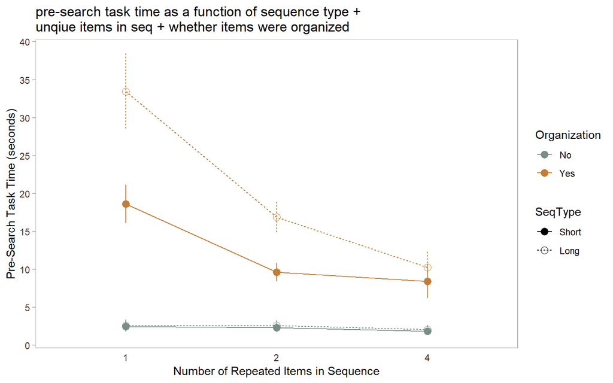

```r
graph1<-ddply(e2, .(SUBJECT, SeqType, Organization, Repetition), summarize,
              mean=mean(PrepTime)
              )

graph2<-ddply(graph1, .(SeqType, Organization, Repetition), summarize,
              dep.avg=mean(mean, na.rm=T),
              dep.sd=sd(mean, na.rm=T),
              dep.count=length(mean),
              dep.ci=dep.sd*qt(0.975,df=dep.count-1)/sqrt(dep.count))
# print(graph2)

graph2$Repetition<-factor(graph2$Repetition)

ggplot(graph2, aes(x=Repetition, y=dep.avg, colour=Organization, shape=SeqType, linetype=SeqType, group=interaction(Organization, SeqType)))+
  geom_point(size=3, position = position_dodge(0))+
  geom_errorbar(aes(ymax=dep.avg+dep.ci,
                    ymin=dep.avg-dep.ci),
                    width=0, position = position_dodge(0))+
  geom_line()+
  theme(
    panel.background= element_rect(fill=NA), # transparent panel
    plot.background = element_rect(fill=NA, colour=NA), #transparent background
    panel.grid=element_blank(), # remove panel grid
    axis.ticks.x=element_blank(), # remove tick marks on x-axis
    axis.ticks=element_line(colour="gray70"), # change colour of tick marks
    panel.border = element_rect(fill="transparent", colour="gray70"), # change panel border colour
    legend.background = element_rect(fill = "transparent", colour = "transparent"), # change legend background
    axis.text = element_text(color="#432620"),
    legend.key = element_rect(fill = "transparent", colour = "transparent")
  )+
  scale_shape_manual(values=c(16, 1))+
  ggtitle("pre-search task time as a function of sequence type + \nunqiue items in seq + whether items were organized")+
  scale_colour_manual(values=wes_palette(n=2, name="Moonrise2"))+
  scale_x_discrete("Number of Repeated Items in Sequence")+
  scale_y_continuous("Pre-Search Task Time (seconds)", breaks=seq(0, 50, 5))
```

```r
e2<-within(e2, Organization <- relevel(Organization, ref = 1))

pre.rt.mod<-lmer(PrepTime~SeqType*Organization*rep.c+(1|SUBJECT), data = e2, REML=F, na.action="na.omit",
                 contrasts=list(SeqType="contr.sum", Organization="contr.sum"))
tab_model(pre.rt.mod, transform = NULL, show.stat = T, p.val = "wald", digits.p = 2)
```

|  | Prep Time |  |  |  |
| --- | --- | --- | --- | --- |
| Predictors | Estimates | CI | Statistic | p |
| (Intercept) | 9.25 | 8.19 – 10.32 | 17.00 | **<0.001** |
| SeqType1 | -2.34 | -2.71 – -1.97 | -12.49 | **<0.001** |
| Organization1 | -6.60 | -7.10 – -6.09 | -25.45 | **<0.001** |
| rep c | -2.96 | -3.26 – -2.67 | -19.70 | **<0.001** |
| SeqType1:Organization1 | 2.21 | 1.84 – 2.58 | 11.68 | **<0.001** |
| SeqType1:rep.c | 1.02 | 0.72 – 1.32 | 6.75 | **<0.001** |
| Organization1:rep.c | 2.82 | 2.53 – 3.12 | 18.67 | **<0.001** |
| SeqType1:Organization1:rep.c | -0.95 | -1.24 – -0.65 | -6.26 | **<0.001** |
| Random Effects |  |  |  |  |
| σ<sup>2</sup> | 49.69 |  |  |  |
| τ<sub>00</sub> <sub>SUBJECT</sub> | 7.83 |  |  |  |
| ICC | 0.14 |  |  |  |
| N <sub>SUBJECT</sub> | 30 |  |  |  |
| Observations | 1432 |  |  |  |
| Marginal R<sup>2</sup> / Conditional R<sup>2</sup> | 0.588 / 0.644 |  |  |  |

3-way interaction, split on organization

```r
# 3-way interaction, split on organization
pre.rt.mod2<-lmer(PrepTime~SeqType*rep.c+(1|SUBJECT), data = e2[e2$Organization=="No",], REML=F,
                  na.action="na.omit", contrasts=list(SeqType="contr.sum"))
pre.rt.mod3<-lmer(PrepTime~SeqType*rep.c+(1|SUBJECT), data = e2[e2$Organization=="Yes",], REML=F,
                  na.action="na.omit",contrasts=list(SeqType="contr.sum"))
tab_model(pre.rt.mod2, pre.rt.mod3, transform = NULL, show.stat = T, p.val = "wald", digits.p = 2)
```

|  | Prep Time |  |  |  | Prep Time |  |  |  |
| --- | --- | --- | --- | --- | --- | --- | --- | --- |
| Predictors | Estimates | CI | Statistic | p | Estimates | CI | Statistic | p |
| (Intercept) | 2.23 | 1.87 – 2.59 | 12.02 | **<0.001** | 16.24 | 14.56 – 17.93 | 18.90 | **<0.001** |
| SeqType1 | -0.15 | -0.27 – -0.03 | -2.52 | **0.01** | -4.61 | -5.32 – -3.91 | -12.88 | **<0.001** |
| rep c | -0.15 | -0.24 – -0.05 | -3.11 | **<0.001** | -5.80 | -6.37 – -5.23 | -19.95 | **<0.001** |
| SeqType1:rep.c | 0.02 | -0.07 – 0.12 | 0.47 | 0.64 | 1.96 | 1.39 – 2.54 | 6.75 | **<0.001** |
| Random Effects |  |  |  |  |  |  |  |  |
| σ<sup>2</sup> | 2.48 |  |  |  | 91.78 |  |  |  |
| τ<sub>00</sub> | 0.74 <sub>SUBJECT</sub> |  |  |  | 15.37 <sub>SUBJECT</sub> |  |  |  |
| ICC | 0.23 |  |  |  | 0.14 |  |  |  |
| N | 28 <sub>SUBJECT</sub> |  |  |  | 30 <sub>SUBJECT</sub> |  |  |  |
| Observations | 695 |  |  |  | 737 |  |  |  |
| Marginal R<sup>2</sup> / Conditional R<sup>2</sup> | 0.020 / 0.246 |  |  |  | 0.409 / 0.494 |  |  |  |

spliting the seq length * repetition interaction for the organized trials

```r
# spliting the seq length * repetition interaction for the organized trials
pre.rt.mod4<-lmer(PrepTime~rep.c+(1|SUBJECT), data = e2[e2$Organization=="Yes" & e2$SeqType=="Short",],
                  REML=F, na.action="na.omit")
pre.rt.mod5<-lmer(PrepTime~rep.c+(1|SUBJECT), data = e2[e2$Organization=="Yes" & e2$SeqType=="Long",],
                  REML=F, na.action="na.omit")
tab_model(pre.rt.mod4, pre.rt.mod5, transform = NULL, show.stat = T, p.val = "wald", digits.p = 2)
```

|  | Prep Time |  |  |  | Prep Time |  |  |  |
| --- | --- | --- | --- | --- | --- | --- | --- | --- |
| Predictors | Estimates | CI | Statistic | p | Estimates | CI | Statistic | p |
| (Intercept) | 11.86 | 10.60 – 13.11 | 18.51 | **<0.001** | 20.37 | 18.08 – 22.66 | 17.42 | **<0.001** |
| rep c | -3.70 | -4.45 – -2.96 | -9.74 | **<0.001** | -7.74 | -8.59 – -6.89 | -17.89 | **<0.001** |
| Random Effects |  |  |  |  |  |  |  |  |
| σ<sup>2</sup> | 74.46 |  |  |  | 105.96 |  |  |  |
| τ<sub>00</sub> | 4.36 <sub>SUBJECT</sub> |  |  |  | 25.99 <sub>SUBJECT</sub> |  |  |  |
| ICC | 0.06 |  |  |  | 0.20 |  |  |  |
| N | 29 <sub>SUBJECT</sub> |  |  |  | 30 <sub>SUBJECT</sub> |  |  |  |
| Observations | 364 |  |  |  | 373 |  |  |  |
| Marginal R<sup>2</sup> / Conditional R<sup>2</sup> | 0.200 / 0.244 |  |  |  | 0.414 / 0.530 |  |  |  |

Individuals spend less time prior to the search phase of the task if they chose not to organize their environment than if they did (b = -6.60, 95% CI [-7.10 -6.09], t = 25.45, p < .001).

Individuals spent less time when encountered with short than long search sequences (b = -2.34, 95% CI [-2.71, -1.97], t = 12.49, p < .001).

An increase in the number of repeated items was associated with a decrease in time spent prior to the search phase of the task (b = -2.96, 95% CI [-3.26, -2.67], t = 19.70, p < .001)

All two-way interactions were significant (all p < .001). More important, there was a significant three-way interaction (b = -.95, 95% CI [-1.24, -.65], t = 6.26, p < .001). When participants did not organize their environment, time spent in the pre-search pahse of the task differed as a function of sequence length (b = -.15, 95% CI [-.27, -.03], t = 2.52, p = .01) as well as repetition (b = -.15, 95% CI [-.24, -.05], t = 3.11, p < .001). However, the interaction was not significant (b = .02, 95% CI [-.07, .12], t = .47, p = .64). On the other hand, when participants did organize their envirionment, there was a significant two-way interaction between sequence length and number of repeated items (b = 1.96, 95% CI [1.39, 2.54], t = 6.75, p < .001) in addition to a main effect of sequence length (b = -4.61, 95% CI [-5.32, -3.91], t = 12.88, p < .001) and repetition (b = -5.80, 95% CI [-6.37, -5.23], t = 19.95, p < .001). Specifically, although there was a negative relation between time spent and repetition length overall, this relation was significantly steeper on trials with long search sequences (b = -7.74, 95% CI [-8.59, -6.89], t = 17.89, p < .001) than short ones (b = -3.70, 95% CI [-4.45, -2.96], t = 9.74, p < .001).

#### Does average search time differ as a function of sequence type

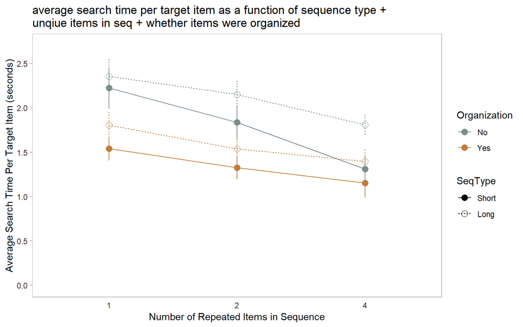

```r
graph1<-ddply(e2, .(SUBJECT, SeqType, Organization, Repetition), summarize,
              mean=mean(SearchTimeAvg)
              )

graph2<-ddply(graph1, .(SeqType, Organization, Repetition), summarize,
              dep.avg=mean(mean, na.rm=T),
              dep.sd=sd(mean, na.rm=T),
              dep.count=length(mean),
              dep.ci=dep.sd*qt(0.975,df=dep.count-1)/sqrt(dep.count))

graph2$Repetition=factor(graph2$Repetition)

ggplot(graph2, aes(x=Repetition, y=dep.avg, colour=Organization, shape=SeqType, linetype=SeqType, group=interaction(Organization, SeqType)))+
  geom_point(size=3, position = position_dodge(0))+
  geom_errorbar(aes(ymax=dep.avg+dep.ci,
                    ymin=dep.avg-dep.ci),
                    width=0, position = position_dodge(0))+
  geom_line()+
  theme(
    panel.background= element_rect(fill=NA), # transparent panel
    plot.background = element_rect(fill=NA, colour=NA), #transparent background
    panel.grid=element_blank(), # remove panel grid
    axis.ticks.x=element_blank(), # remove tick marks on x-axis
    axis.ticks=element_line(colour="gray70"), # change colour of tick marks
    panel.border = element_rect(fill="transparent", colour="gray70"), # change panel border colour
    legend.background = element_rect(fill = "transparent", colour = "transparent"), # change legend background
    axis.text = element_text(color="#432620"),
    legend.key = element_rect(fill = "transparent", colour = "transparent")
  )+
  scale_shape_manual(values=c(16, 1))+
  ggtitle("average search time per target item as a function of sequence type + \nunqiue items in seq + whether items were organized")+
  scale_colour_manual(values=wes_palette(n=2, name="Moonrise2"))+
  scale_x_discrete("Number of Repeated Items in Sequence")+
  scale_y_continuous("Average Search Time Per Target Item (seconds)", breaks=seq(0, 10, 0.5), limits=c(0, 2.7))
```

```r
post.rt.mod<-lmer(SearchTimeAvg~SeqType*Organization*rep.c+(1|SUBJECT), data = e2, REML=F, na.action="na.omit",
                  contrasts=list(SeqType="contr.sum", Organization="contr.sum"))
tab_model(post.rt.mod, transform = NULL, show.stat = T, p.val = "wald", digits = 3, digits.p = 2)
```

|  | Search Time Avg |  |  |  |
| --- | --- | --- | --- | --- |
| Predictors | Estimates | CI | Statistic | p |
| (Intercept) | 1.641 | 1.553 – 1.729 | 36.537 | **<0.001** |
| SeqType1 | -0.114 | -0.133 – -0.096 | -12.100 | **<0.001** |
| Organization1 | 0.203 | 0.176 – 0.229 | 14.931 | **<0.001** |
| rep c | -0.168 | -0.183 – -0.153 | -22.170 | **<0.001** |
| SeqType1:Organization1 | 0.011 | -0.008 – 0.030 | 1.153 | 0.25 |
| SeqType1:rep.c | -0.020 | -0.035 – -0.006 | -2.695 | **0.01** |
| Organization1:rep.c | -0.036 | -0.051 – -0.021 | -4.763 | **<0.001** |
| SeqType1:Organization1:rep.c | -0.017 | -0.032 – -0.002 | -2.268 | **0.02** |
| Random Effects |  |  |  |  |
| σ<sup>2</sup> | 0.13 |  |  |  |
| τ<sub>00</sub> <sub>SUBJECT</sub> | 0.06 |  |  |  |
| ICC | 0.32 |  |  |  |
| N <sub>SUBJECT</sub> | 30 |  |  |  |
| Observations | 1432 |  |  |  |
| Marginal R<sup>2</sup> / Conditional R<sup>2</sup> | 0.346 / 0.552 |  |  |  |

3 way interaction split on organization

```r
# 3 way interaction split on organization
post.rt.mod2<-lmer(SearchTimeAvg~SeqType*rep.c+(1|SUBJECT), data = e2[e2$Organization=="Yes",],
                   REML=F, na.action="na.omit", contrasts = list(SeqType="contr.sum"))
post.rt.mod3<-lmer(SearchTimeAvg~SeqType*rep.c+(1|SUBJECT), data = e2[e2$Organization=="No",],
                   REML=F, na.action="na.omit", contrasts = list(SeqType="contr.sum"))
tab_model(post.rt.mod2, post.rt.mod3, transform = NULL, show.stat = T, p.val = "wald", digits.p = 2)
```

|  | Search Time Avg |  |  |  | Search Time Avg |  |  |  |
| --- | --- | --- | --- | --- | --- | --- | --- | --- |
| Predictors | Estimates | CI | Statistic | p | Estimates | CI | Statistic | p |
| (Intercept) | 1.51 | 1.39 – 1.62 | 25.38 | **<0.001** | 1.90 | 1.80 – 2.01 | 34.76 | **<0.001** |
| SeqType1 | -0.13 | -0.14 – -0.11 | -13.59 | **<0.001** | -0.10 | -0.13 – -0.07 | -6.04 | **<0.001** |
| rep c | -0.13 | -0.14 – -0.12 | -17.41 | **<0.001** | -0.20 | -0.23 – -0.18 | -15.80 | **<0.001** |
| SeqType1:rep.c | -0.00 | -0.02 – 0.01 | -0.53 | 0.60 | -0.04 | -0.07 – -0.02 | -3.37 | **<0.001** |
| Random Effects |  |  |  |  |  |  |  |  |
| σ<sup>2</sup> | 0.06 |  |  |  | 0.18 |  |  |  |
| τ<sub>00</sub> | 0.10 <sub>SUBJECT</sub> |  |  |  | 0.07 <sub>SUBJECT</sub> |  |  |  |
| ICC | 0.62 |  |  |  | 0.27 |  |  |  |
| N | 30 <sub>SUBJECT</sub> |  |  |  | 28 <sub>SUBJECT</sub> |  |  |  |
| Observations | 737 |  |  |  | 695 |  |  |  |
| Marginal R<sup>2</sup> / Conditional R<sup>2</sup> | 0.189 / 0.693 |  |  |  | 0.260 / 0.461 |  |  |  |

breaking down previous two-way interaction

```r
# breaking down previous two-way interaction
post.rt.mod4<-lmer(SearchTimeAvg~rep.c+(1|SUBJECT), data = e2[e2$Organization=="No" & e2$SeqType=="Short",],
                   REML=F, na.action="na.omit")
post.rt.mod5<-lmer(SearchTimeAvg~rep.c+(1|SUBJECT), data = e2[e2$Organization=="No" & e2$SeqType=="Long",],
                   REML=F, na.action="na.omit")
tab_model(post.rt.mod4, post.rt.mod5, transform = NULL, show.stat = T, p.val = "wald", digits.p = 2)
```

|  | Search Time Avg |  |  |  | Search Time Avg |  |  |  |
| --- | --- | --- | --- | --- | --- | --- | --- | --- |
| Predictors | Estimates | CI | Statistic | p | Estimates | CI | Statistic | p |
| (Intercept) | 1.75 | 1.62 – 1.89 | 25.58 | **<0.001** | 2.10 | 2.00 – 2.20 | 41.28 | **<0.001** |
| rep c | -0.24 | -0.28 – -0.20 | -11.54 | **<0.001** | -0.16 | -0.19 – -0.13 | -10.26 | **<0.001** |
| Random Effects |  |  |  |  |  |  |  |  |
| σ<sup>2</sup> | 0.22 |  |  |  | 0.12 |  |  |  |
| τ<sub>00</sub> | 0.09 <sub>SUBJECT</sub> |  |  |  | 0.05 <sub>SUBJECT</sub> |  |  |  |
| ICC | 0.30 |  |  |  | 0.29 |  |  |  |
| N | 27 <sub>SUBJECT</sub> |  |  |  | 25 <sub>SUBJECT</sub> |  |  |  |
| Observations | 350 |  |  |  | 345 |  |  |  |
| Marginal R<sup>2</sup> / Conditional R<sup>2</sup> | 0.222 / 0.453 |  |  |  | 0.184 / 0.417 |  |  |  |

When individuals did not organized the task environment prior to search, they spend more time searching for each target item on average than trials where they organize the environment (b = .20, 95% CI [.18, .23], t = 14.93, p < .001).

Overall, it takes individuals less time to search for each target when they are presented in a short sequence than a long one (b = -.11, 95% CI [-.13, -.10], t = 12.10, p < .001).

As the number of times that items are repeated increased, the amount of time spent searching per target decreased (b = -.17, 95% CI [-.18, -.15], t = 22.17, p < .001).

There was a two-way interaction between sequence length and repetition length (b = -.02, 95% CI [-.04, -.01], t = 2.69, p = .01).

There was also a two-way interaction between choice to organize and repetition length (b = -.04, 95% CI [-.05, -.02], t = 4.76, p < .001).

Importantly, there was a three-way interaction (b = -.02, 95% CI [-.03, -.002] t = 2.27, p = .02). When participants engaged in organization, it took less time to search for items on trials with short sequences than long ones (b = .13, 95% CI [-.14, -.11], t = 13.59, p < .001) and decreased with increased repetition length (b = -.13, 95% CI [-.14, -.12], t = 17.41, p < .001). On the other hand, though these same main effects emerged when individuals did not engage in organization, these main effects were qualified by a two-way interaction between sequence and repetition length (b = -.04, 95% CI [-.07, -.02], t = 3.37, p < .001). While both types of sequence length resulted in a negative relation between time spend per item during search, this relation was steeper for short sequences (b = -.24, 95% CI [-.28, -.20], t = 11.54, p < .001) than long ones (b = .16, 95% CI [-.19, -.13], t = 10.26, p < .001).

### Organizational Moves: Trial-Level Organization

#### Did decision to organize (Y/N) change as a function of sequence type?

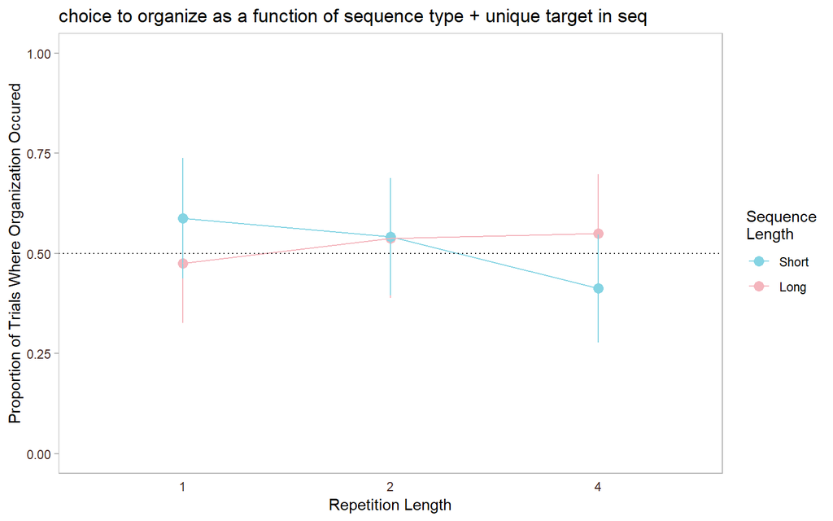

```r
graph1<-ddply(e2, .(SUBJECT, SeqType, Repetition), summarize,
              mean=mean(Org.Num)
              )

graph2<-ddply(graph1, .(SeqType, Repetition), summarize,
              dep.avg=mean(mean, na.rm=T),
              dep.sd=sd(mean, na.rm=T),
              dep.count=length(mean),
              dep.ci=dep.sd*qt(0.975,df=dep.count-1)/sqrt(dep.count))

graph2$Repetition=factor(graph2$Repetition)

ggplot(graph2, aes(x=Repetition, y=dep.avg, colour=SeqType, group=SeqType))+
  geom_point(size=3, shape=16, position = position_dodge(0))+
  geom_errorbar(aes(ymax=dep.avg+dep.ci,
                    ymin=dep.avg-dep.ci),
                    width=0, position = position_dodge(0))+
  geom_line()+
  theme(
    panel.background= element_rect(fill=NA), # transparent panel
    plot.background = element_rect(fill=NA, colour=NA), #transparent background
    panel.grid=element_blank(), # remove panel grid
    axis.ticks.x=element_blank(), # remove tick marks on x-axis
    axis.ticks=element_line(colour="gray70"), # change colour of tick marks
    panel.border = element_rect(fill="transparent", colour="gray70"), # change panel border colour
    legend.background = element_rect(fill = "transparent", colour = "transparent"), # change legend background
    axis.text = element_text(color="#432620"),
    legend.key = element_rect(fill = "transparent", colour = "transparent")
  )+
  ggtitle("choice to organize as a function of sequence type + unique target in seq")+
  geom_hline(yintercept = 0.5, linetype="dotted")+
  scale_colour_manual("Sequence\nLength", values=wes_palette("Moonrise3", n=2))+
  scale_x_discrete("Repetition Length")+
  scale_y_continuous("Proportion of Trials Where Organization Occured", limits=c(0, 1))
```

```r
moves.mod<-glmer(Org.Num ~ SeqType*rep.c + (1 | SUBJECT), data = e2, family = binomial,
                 contrasts = list (SeqType="contr.sum"))
tab_model(moves.mod, transform = NULL, show.stat = T, p.val = "wald", digits.p = 2)
```

|  | Org Num |  |  |  |
| --- | --- | --- | --- | --- |
| Predictors | Log-Odds | CI | Statistic | p |
| (Intercept) | 0.28 | -0.62 – 1.17 | 0.60 | 0.55 |
| SeqType1 | -0.03 | -0.18 – 0.12 | -0.44 | 0.66 |
| rep c | -0.16 | -0.28 – -0.04 | -2.62 | **0.01** |
| SeqType1:rep.c | -0.35 | -0.48 – -0.23 | -5.61 | **<0.001** |
| Random Effects |  |  |  |  |
| σ<sup>2</sup> | 3.29 |  |  |  |
| τ<sub>00</sub> <sub>SUBJECT</sub> | 5.99 |  |  |  |
| ICC | 0.65 |  |  |  |
| N <sub>SUBJECT</sub> | 30 |  |  |  |
| Observations | 1432 |  |  |  |
| Marginal R<sup>2</sup> / Conditional R<sup>2</sup> | 0.025 / 0.654 |  |  |  |

```r
# two-way interaction
moves.mod2<-glmer(Org.Num ~ rep.c + (1 | SUBJECT), data = e2[e2$SeqType=="Short",], family = binomial)
moves.mod3<-glmer(Org.Num ~ rep.c + (1 | SUBJECT), data = e2[e2$SeqType=="Long",], family = binomial)
tab_model(moves.mod2, moves.mod3, transform = NULL, show.stat = T, p.val = "wald", digits.p = 2)
```

|  | Org Num |  |  |  | Org Num |  |  |  |
| --- | --- | --- | --- | --- | --- | --- | --- | --- |
| Predictors | Log-Odds | CI | Statistic | p | Log-Odds | CI | Statistic | p |
| (Intercept) | 0.21 | -0.72 – 1.14 | 0.44 | 0.66 | 0.44 | -0.58 – 1.46 | 0.85 | 0.40 |
| rep c | -0.51 | -0.69 – -0.33 | -5.58 | **<0.001** | 0.20 | 0.03 – 0.37 | 2.30 | **0.02** |
| Random Effects |  |  |  |  |  |  |  |  |
| σ<sup>2</sup> | 3.29 |  |  |  | 3.29 |  |  |  |
| τ<sub>00</sub> | 6.21 <sub>SUBJECT</sub> |  |  |  | 7.48 <sub>SUBJECT</sub> |  |  |  |
| ICC | 0.65 |  |  |  | 0.69 |  |  |  |
| N | 30 <sub>SUBJECT</sub> |  |  |  | 30 <sub>SUBJECT</sub> |  |  |  |
| Observations | 714 |  |  |  | 718 |  |  |  |
| Marginal R<sup>2</sup> / Conditional R<sup>2</sup> | 0.041 / 0.668 |  |  |  | 0.006 / 0.696 |  |  |  |

Overall, sequence length was not a significant predictor of participants’ likelihood to engage in organization (b = -.03, 95% CI [-.18, .12], z = .44, p = .66).

As repetition length increased, likelihood of engaging in organization decreased (b = -.16, 95% CI [-.28, -.04], t= 2.62, p = .01).

However, this was quantified by a significant two-way interaction between repetition and sequence length (b = -.35, 95% CI [-.48, -.23], z = 5.61, p < .001). That is, when participants are shown short target sequences, their tendency to organize the task environment decreases with repetition (b = -.51, 95% CI [.69, -.33], z = 5.58, p < .001). However, when shown long sequence lengths, individuals were more likely to organize their environments with increased repetition length (b = .2, 95% CI [.03, .37], z = 2.30, p = .02).

#### Decision to Organize (Y/N) as a function of sequence type across time

##### Overall

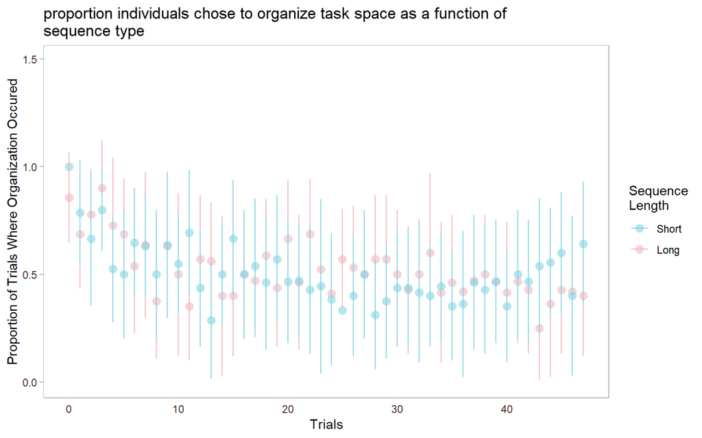

```r
graph1<-ddply(e2, .(SUBJECT, SeqType, TRIAL), summarize,
              mean=mean(Org.Num)
              )

graph2<-ddply(graph1, .(SeqType, TRIAL), summarize,
              dep.avg=mean(mean, na.rm=T),
              dep.sd=sd(mean, na.rm=T),
              dep.count=length(mean),
              dep.ci=dep.sd*qt(0.975,df=dep.count-1)/sqrt(dep.count))

ggplot(graph2, aes(x=TRIAL, y=dep.avg, colour=SeqType))+
  geom_point(size=3, shape=16, alpha = .6, position = position_dodge(0))+
  geom_errorbar(aes(ymax=dep.avg+dep.ci,
                    ymin=dep.avg-dep.ci),
                    width=0, position = position_dodge(0))+
  theme(
    panel.background= element_rect(fill=NA), # transparent panel
    plot.background = element_rect(fill=NA, colour=NA), #transparent background
    panel.grid=element_blank(), # remove panel grid
    axis.ticks.x=element_blank(), # remove tick marks on x-axis
    axis.ticks=element_line(colour="gray70"), # change colour of tick marks
    panel.border = element_rect(fill="transparent", colour="gray70"), # change panel border colour
    legend.background = element_rect(fill = "transparent", colour = "transparent"), # change legend background
    axis.text = element_text(color="#432620"),
    legend.key = element_rect(fill = "transparent", colour = "transparent")
  )+
  ggtitle("proportion individuals chose to organize task space as a function of \nsequence type")+
  # geom_vline(xintercept = 6, linetype="dotted")+
  scale_colour_manual("Sequence\nLength", values=wes_palette("Moonrise3", n=2))+
  scale_x_continuous("Trials")+
  scale_y_continuous("Proportion of Trials Where Organization Occured", limits=c(0, 1.49))
```

##### Faceted on Repetition Length

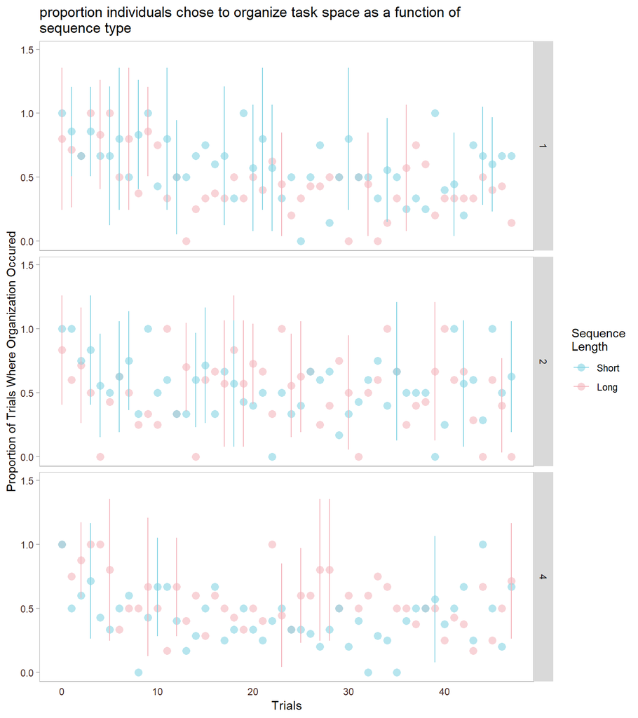

```r
graph1<-ddply(e2, .(SUBJECT, SeqType, TRIAL, Repetition), summarize,
              mean=mean(Org.Num)
              )

graph2<-ddply(graph1, .(SeqType, TRIAL, Repetition), summarize,
              dep.avg=mean(mean, na.rm=T),
              dep.sd=sd(mean, na.rm=T),
              dep.count=length(mean),
              dep.ci=dep.sd*qt(0.975,df=dep.count-1)/sqrt(dep.count))
graph2$Repetition=factor(graph2$Repetition)

ggplot(graph2, aes(x=TRIAL, y=dep.avg, colour=SeqType))+
  geom_point(size=3, shape=16, alpha = .6, position = position_dodge(0))+
  geom_errorbar(aes(ymax=dep.avg+dep.ci,
                    ymin=dep.avg-dep.ci),
                    width=0, position = position_dodge(0))+
  facet_grid(Repetition~.)+
  theme(
    panel.background= element_rect(fill=NA), # transparent panel
    plot.background = element_rect(fill=NA, colour=NA), #transparent background
    panel.grid=element_blank(), # remove panel grid
    axis.ticks.x=element_blank(), # remove tick marks on x-axis
    axis.ticks=element_line(colour="gray70"), # change colour of tick marks
    panel.border = element_rect(fill="transparent", colour="gray70"), # change panel border colour
    legend.background = element_rect(fill = "transparent", colour = "transparent"), # change legend background
    axis.text = element_text(color="#432620"),
    legend.key = element_rect(fill = "transparent", colour = "transparent")
  )+
  ggtitle("proportion individuals chose to organize task space as a function of \nsequence type")+
  # geom_vline(xintercept = 6, linetype="dotted")+
  scale_colour_manual("Sequence\nLength", values=wes_palette("Moonrise3", n=2))+
  scale_x_continuous("Trials")+
  scale_y_continuous("Proportion of Trials Where Organization Occured", limits=c(0, 1.49))
```

```r
moves.mod4<-glmer(Org.Num ~ trial.c*SeqType*rep.c+(1|SUBJECT), data = e2, family = binomial(link = logit),
                  contrasts=list(SeqType="contr.sum"))
tab_model(moves.mod4, transform = NULL, show.stat = T, p.val = "wald", digits.p = 2)
```

|  | Org Num |  |  |  |
| --- | --- | --- | --- | --- |
| Predictors | Log-Odds | CI | Statistic | p |
| (Intercept) | 0.29 | -0.68 – 1.25 | 0.59 | 0.56 |
| trial c | -0.05 | -0.06 – -0.04 | -7.88 | **<0.001** |
| SeqType1 | -0.05 | -0.20 – 0.11 | -0.62 | 0.53 |
| rep c | -0.19 | -0.31 – -0.06 | -2.91 | **<0.001** |
| trial.c:SeqType1 | -0.00 | -0.01 – 0.01 | -0.10 | 0.92 |
| trial.c:rep.c | 0.01 | -0.00 – 0.02 | 1.68 | 0.09 |
| SeqType1:rep.c | -0.39 | -0.52 – -0.26 | -5.87 | **<0.001** |
| trial.c:SeqType1:rep.c | 0.00 | -0.01 – 0.01 | 0.31 | 0.75 |
| Random Effects |  |  |  |  |
| σ<sup>2</sup> | 3.29 |  |  |  |
| τ<sub>00</sub> <sub>SUBJECT</sub> | 6.92 |  |  |  |
| ICC | 0.68 |  |  |  |
| N <sub>SUBJECT</sub> | 30 |  |  |  |
| Observations | 1432 |  |  |  |
| Marginal R<sup>2</sup> / Conditional R<sup>2</sup> | 0.069 / 0.700 |  |  |  |

When number of trials was added to the model, it was negatively associated with individuals’ likelihood to organize their task environments (b = -.05, 95% CI [-.06, -.04], t = 7.88, p < .001). No additional factors or interactions were significant (all p > .09)

#### Item Location (Trial)

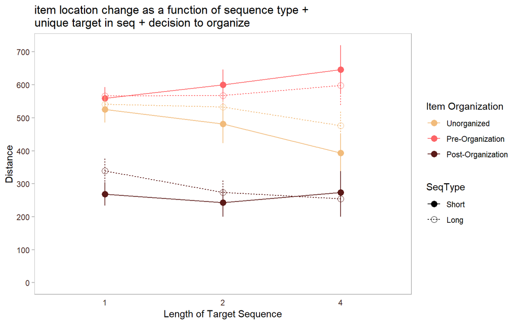

```r
graph1<-ddply(e2.org, .(SUBJECT, Arrangement, SeqType, Repetition), summarize,
              mean=mean(Distance)
              )

graph2<-ddply(graph1, .(Arrangement, SeqType, Repetition), summarize,
              dep.avg=mean(mean, na.rm=T),
              dep.sd=sd(mean, na.rm=T),
              dep.count=length(mean),
              dep.ci=dep.sd*qt(0.975,df=dep.count-1)/sqrt(dep.count))

graph2$Repetition=factor(graph2$Repetition)

ggplot(graph2, aes(x=Repetition, y=dep.avg, shape=SeqType, colour=Arrangement, linetype=SeqType, group=interaction(Arrangement, SeqType)))+
  geom_point(size=3, position = position_dodge(0))+
  geom_errorbar(aes(ymax=dep.avg+dep.ci,
                    ymin=dep.avg-dep.ci),
                    width=0, position = position_dodge(0))+
  geom_line()+
  theme(
    panel.background= element_rect(fill=NA), # transparent panel
    plot.background = element_rect(fill=NA, colour=NA), #transparent background
    panel.grid=element_blank(), # remove panel grid
    axis.ticks.x=element_blank(), # remove tick marks on x-axis
    axis.ticks=element_line(colour="gray70"), # change colour of tick marks
    panel.border = element_rect(fill="transparent", colour="gray70"), # change panel border colour
    legend.background = element_rect(fill = "transparent", colour = "transparent"), # change legend background
    axis.text = element_text(color="#432620"),
    legend.key = element_rect(fill = "transparent", colour = "transparent")
  )+
  scale_shape_manual(values=c(16,1))+
  ggtitle("item location change as a function of sequence type + \nunique target in seq + decision to organize")+
  scale_colour_manual("Item Organization", values=wes_palette(n=3, name="GrandBudapest1"))+
  scale_x_discrete("Length of Target Sequence")+
  scale_y_continuous("Distance", limits=c(0, 720), breaks=seq(0, 1000, 100))
```

```r
e2.org.sub<-subset(e2.org, Arrangement!="Unorganized")
arr.mod<-lmer(Distance~SeqType*Arrangement*rep.c+(1|SUBJECT), data = e2.org.sub, REML=F, na.action="na.omit",
              contrasts=list(SeqType="contr.sum", Arrangement="contr.sum"))
tab_model(arr.mod, transform = NULL, show.stat = T, p.val = "wald", digits.p = 2)
```

|  | Distance |  |  |  |
| --- | --- | --- | --- | --- |
| Predictors | Estimates | CI | Statistic | p |
| (Intercept) | 429.51 | 411.56 – 447.46 | 46.91 | **<0.001** |
| SeqType1 | -3.04 | -9.68 – 3.60 | -0.90 | 0.37 |
| Arrangement1 | 173.99 | 167.41 – 180.57 | 51.83 | **<0.001** |
| rep c | -0.60 | -5.99 – 4.79 | -0.22 | 0.83 |
| SeqType1:Arrangement1 | 14.81 | 8.23 – 21.39 | 4.41 | **<0.001** |
| SeqType1:rep.c | 6.95 | 1.55 – 12.35 | 2.52 | **0.01** |
| Arrangement1:rep.c | 17.60 | 12.24 – 22.96 | 6.44 | **<0.001** |
| SeqType1:Arrangement1:rep.c | -0.45 | -5.81 – 4.91 | -0.16 | 0.87 |
| Random Effects |  |  |  |  |
| σ<sup>2</sup> | 16427.56 |  |  |  |
| τ<sub>00</sub> <sub>SUBJECT</sub> | 1869.69 |  |  |  |
| ICC | 0.10 |  |  |  |
| N <sub>SUBJECT</sub> | 30 |  |  |  |
| Observations | 1474 |  |  |  |
| Marginal R<sup>2</sup> / Conditional R<sup>2</sup> | 0.627 / 0.665 |  |  |  |

seq length * arrangement:

```r
# seq length * arrangement
arr.mod2<-lmer(Distance~SeqType+(1|SUBJECT), data = e2.org.sub[e2.org.sub$Arrangement=="Pre-Organization",],
               REML=F, na.action="na.omit", contrasts = list(SeqType="contr.sum"))
arr.mod3<-lmer(Distance~SeqType+(1|SUBJECT), data = e2.org.sub[e2.org.sub$Arrangement=="Post-Organization",],
               REML=F, na.action="na.omit", contrasts = list(SeqType="contr.sum"))
tab_model(arr.mod2, arr.mod3, transform = NULL, show.stat = T, p.val = "wald", digits.p = 2)
```

|  | Distance |  |  |  | Distance |  |  |  |
| --- | --- | --- | --- | --- | --- | --- | --- | --- |
| Predictors | Estimates | CI | Statistic | p | Estimates | CI | Statistic | p |
| (Intercept) | 588.04 | 567.61 – 608.47 | 56.41 | **<0.001** | 278.83 | 247.74 – 309.91 | 17.58 | **<0.001** |
| SeqType1 | 8.82 | -2.15 – 19.79 | 1.58 | 0.11 | -14.81 | -21.49 – -8.13 | -4.34 | **<0.001** |
| Random Effects |  |  |  |  |  |  |  |  |
| σ<sup>2</sup> | 22788.68 |  |  |  | 8379.71 |  |  |  |
| τ<sub>00</sub> | 1831.18 <sub>SUBJECT</sub> |  |  |  | 6741.80 <sub>SUBJECT</sub> |  |  |  |
| ICC | 0.07 |  |  |  | 0.45 |  |  |  |
| N | 30 <sub>SUBJECT</sub> |  |  |  | 30 <sub>SUBJECT</sub> |  |  |  |
| Observations | 737 |  |  |  | 737 |  |  |  |
| Marginal R<sup>2</sup> / Conditional R<sup>2</sup> | 0.003 / 0.077 |  |  |  | 0.014 / 0.454 |  |  |  |

seq length * repetition:

```r
# seq length * repetition
arr.mod4<-lmer(Distance~rep.c+(1|SUBJECT), data = e2.org.sub[e2.org.sub$SeqType=="Short",],
               REML=F, na.action="na.omit")
arr.mod5<-lmer(Distance~rep.c+(1|SUBJECT), data = e2.org.sub[e2.org.sub$SeqType=="Long",],
               REML=F, na.action="na.omit")
tab_model(arr.mod4, arr.mod5, transform = NULL, show.stat = T, p.val = "wald", digits.p = 2)
```

|  | Distance |  |  |  | Distance |  |  |  |
| --- | --- | --- | --- | --- | --- | --- | --- | --- |
| Predictors | Estimates | CI | Statistic | p | Estimates | CI | Statistic | p |
| (Intercept) | 414.15 | 396.71 – 431.59 | 46.54 | **<0.001** | 422.05 | 404.57 – 439.52 | 47.33 | **<0.001** |
| rep c | 6.09 | -8.35 – 20.53 | 0.83 | 0.41 | -7.49 | -19.03 – 4.05 | -1.27 | 0.20 |
| Random Effects |  |  |  |  |  |  |  |  |
| σ<sup>2</sup> | 56660.52 |  |  |  | 39890.98 |  |  |  |
| τ<sub>00</sub> | 0.00 <sub>SUBJECT</sub> |  |  |  | 530.09 <sub>SUBJECT</sub> |  |  |  |
| ICC |  |  |  |  | 0.01 |  |  |  |
| N | 29 <sub>SUBJECT</sub> |  |  |  | 30 <sub>SUBJECT</sub> |  |  |  |
| Observations | 728 |  |  |  | 746 |  |  |  |
| Marginal R<sup>2</sup> / Conditional R<sup>2</sup> | 0.002 / 0.015 |  |  |  |  |  |  |  |

arrangement * rep.c:

```r
# arrangement * rep.c
arr.mod6<-lmer(Distance~rep.c+(1|SUBJECT), data = e2.org.sub[e2.org.sub$Arrangement=="Pre-Organization",],
               REML=F, na.action="na.omit")
arr.mod7<-lmer(Distance~rep.c+(1|SUBJECT), data = e2.org.sub[e2.org.sub$Arrangement=="Post-Organization",],
               REML=F, na.action="na.omit")
tab_model(arr.mod6, arr.mod7, transform = NULL, show.stat = T, p.val = "wald", digits.p = 2)
```

|  | Distance |  |  |  | Distance |  |  |  |
| --- | --- | --- | --- | --- | --- | --- | --- | --- |
| Predictors | Estimates | CI | Statistic | p | Estimates | CI | Statistic | p |
| (Intercept) | 588.62 | 568.27 – 608.97 | 56.69 | **<0.001** | 278.36 | 247.42 – 309.29 | 17.63 | **<0.001** |
| rep c | 14.75 | 5.90 – 23.61 | 3.27 | **<0.001** | -15.75 | -21.11 – -10.39 | -5.76 | **<0.001** |
| Random Effects |  |  |  |  |  |  |  |  |
| σ<sup>2</sup> | 22537.15 |  |  |  | 8220.79 |  |  |  |
| τ<sub>00</sub> | 1818.85 <sub>SUBJECT</sub> |  |  |  | 6683.24 <sub>SUBJECT</sub> |  |  |  |
| ICC | 0.07 |  |  |  | 0.45 |  |  |  |
| N | 30 <sub>SUBJECT</sub> |  |  |  | 30 <sub>SUBJECT</sub> |  |  |  |
| Observations | 737 |  |  |  | 737 |  |  |  |
| Marginal R<sup>2</sup> / Conditional R<sup>2</sup> | 0.013 / 0.087 |  |  |  | 0.025 / 0.462 |  |  |  |

(pre- vs post-organization)

Items were located further away from the goal location pre-organization and moved closer post-organization (b = 173.99, 95% CI [167.41, 180.57], t = 51.83, p < .001)

There was a significant two-way interaction between sequence length across organizational states (b = 14.81, 95% CI [8.23, 21.39], t = 4.41, p < .001). Specifically, prior to organization, item distance did not differ as a function of sequence length (b = 8.82, 95% CI [-2.15, 19.79], t = 1.58, p = .11). However, post-organization, items tend to be placed closer to the goal location when individuals are presented with short rather than long target sequences (b = -14.81, 95% CI [-21.49, -8.13], t = 4.34, p < .001).

There was also a significant two-way interaction between repetition and sequence length (b = 6.95, 95% CI [1.55, 12.35], t = 2.52, p = .01). However, there was no relation between repetition and item distance both for short (b = 6.09, 95% CI [-8.35, 20.53], t = .83, p = .41) and long sequences (b = -7.49, 95% CI [19.03, 4.05], t = 1.27, p = .20)

Finally, there was a significant two-way interaction between organizational states and repetition (b = 17.60, 95% CI [12.24, 22.96], t = 6.44, p < .001). Prior to organization, increased repetition length was associated with increased average item distance to the goal location (b = 14.75, 95% CI [5.90, 23.61], t = 3.27, p < .001); however, post-organization, this pattern reversed, such that an increase in repetition length led to decreased average item distance (b = -15.75, 95% CI [-21.11, -10.39], t = 5.76, p < .001)

###### (Graph of the seq length x pre/post organization beow)

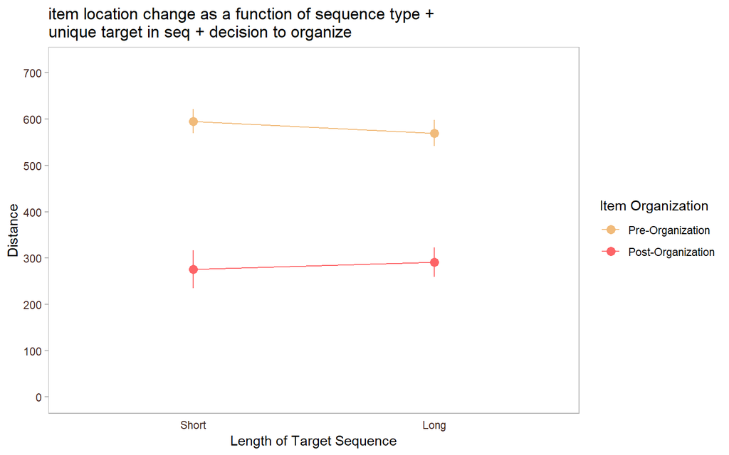

```r
graph1<-ddply(e2.org.sub, .(SUBJECT, Arrangement, SeqType), summarize,
              mean=mean(Distance)
              )

graph2<-ddply(graph1, .(Arrangement, SeqType), summarize,
              dep.avg=mean(mean, na.rm=T),
              dep.sd=sd(mean, na.rm=T),
              dep.count=length(mean),
              dep.ci=dep.sd*qt(0.975,df=dep.count-1)/sqrt(dep.count))


ggplot(graph2, aes(x=SeqType, y=dep.avg, colour=Arrangement, group=Arrangement))+
  geom_point(size=3, position = position_dodge(0))+
  geom_errorbar(aes(ymax=dep.avg+dep.ci,
                    ymin=dep.avg-dep.ci),
                    width=0, position = position_dodge(0))+
  geom_line()+
  theme(
    panel.background= element_rect(fill=NA), # transparent panel
    plot.background = element_rect(fill=NA, colour=NA), #transparent background
    panel.grid=element_blank(), # remove panel grid
    axis.ticks.x=element_blank(), # remove tick marks on x-axis
    axis.ticks=element_line(colour="gray70"), # change colour of tick marks
    panel.border = element_rect(fill="transparent", colour="gray70"), # change panel border colour
    legend.background = element_rect(fill = "transparent", colour = "transparent"), # change legend background
    axis.text = element_text(color="#432620"),
    legend.key = element_rect(fill = "transparent", colour = "transparent")
  )+
  scale_shape_manual(values=c(16,1))+
  ggtitle("item location change as a function of sequence type + \nunique target in seq + decision to organize")+
  scale_colour_manual("Item Organization", values=wes_palette(n=3, name="GrandBudapest1"))+
  scale_x_discrete("Length of Target Sequence")+
  scale_y_continuous("Distance", limits=c(0, 720), breaks=seq(0, 1000, 100))
```

###### (graph for the sequence length x repetition interaction)

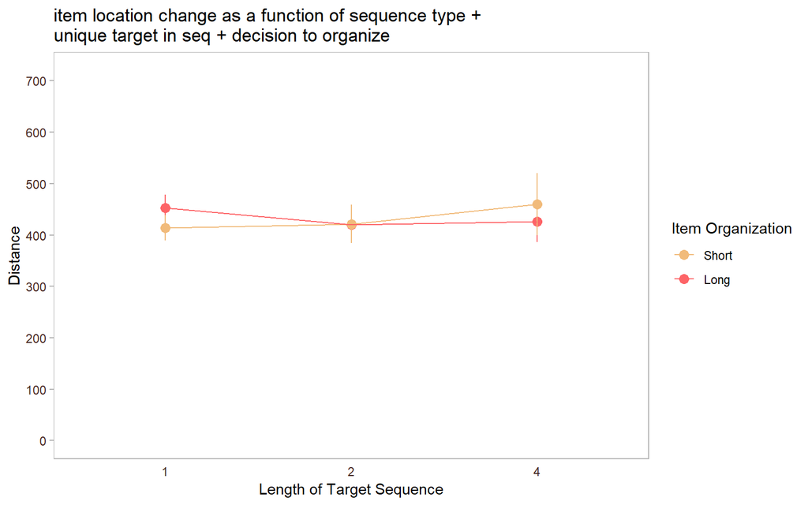

```r
graph1<-ddply(e2.org.sub, .(SUBJECT, SeqType, Repetition), summarize,
              mean=mean(Distance)
              )

graph2<-ddply(graph1, .(SeqType, Repetition), summarize,
              dep.avg=mean(mean, na.rm=T),
              dep.sd=sd(mean, na.rm=T),
              dep.count=length(mean),
              dep.ci=dep.sd*qt(0.975,df=dep.count-1)/sqrt(dep.count))

graph2$Repetition=factor(graph2$Repetition)

ggplot(graph2, aes(x=Repetition, y=dep.avg, colour=SeqType, group=SeqType))+
  geom_point(size=3, position = position_dodge(0))+
  geom_errorbar(aes(ymax=dep.avg+dep.ci,
                    ymin=dep.avg-dep.ci),
                    width=0, position = position_dodge(0))+
  geom_line()+
  theme(
    panel.background= element_rect(fill=NA), # transparent panel
    plot.background = element_rect(fill=NA, colour=NA), #transparent background
    panel.grid=element_blank(), # remove panel grid
    axis.ticks.x=element_blank(), # remove tick marks on x-axis
    axis.ticks=element_line(colour="gray70"), # change colour of tick marks
    panel.border = element_rect(fill="transparent", colour="gray70"), # change panel border colour
    legend.background = element_rect(fill = "transparent", colour = "transparent"), # change legend background
    axis.text = element_text(color="#432620"),
    legend.key = element_rect(fill = "transparent", colour = "transparent")
  )+
  scale_shape_manual(values=c(16,1))+
  ggtitle("item location change as a function of sequence type + \nunique target in seq + decision to organize")+
  scale_colour_manual("Item Organization", values=wes_palette(n=3, name="GrandBudapest1"))+
  scale_x_discrete("Length of Target Sequence")+
  scale_y_continuous("Distance", limits=c(0, 720), breaks=seq(0, 1000, 100))
```

###### (graph for the organization x repetition interaction)

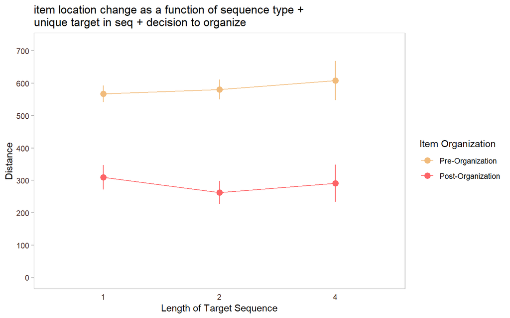

```r
graph1<-ddply(e2.org.sub, .(SUBJECT, Arrangement, Repetition), summarize,
              mean=mean(Distance)
              )

graph2<-ddply(graph1, .(Arrangement, Repetition), summarize,
              dep.avg=mean(mean, na.rm=T),
              dep.sd=sd(mean, na.rm=T),
              dep.count=length(mean),
              dep.ci=dep.sd*qt(0.975,df=dep.count-1)/sqrt(dep.count))

graph2$Repetition=factor(graph2$Repetition)

ggplot(graph2, aes(x=Repetition, y=dep.avg, colour=Arrangement, group=Arrangement))+
  geom_point(size=3, position = position_dodge(0))+
  geom_errorbar(aes(ymax=dep.avg+dep.ci,
                    ymin=dep.avg-dep.ci),
                    width=0, position = position_dodge(0))+
  geom_line()+
  theme(
    panel.background= element_rect(fill=NA), # transparent panel
    plot.background = element_rect(fill=NA, colour=NA), #transparent background
    panel.grid=element_blank(), # remove panel grid
    axis.ticks.x=element_blank(), # remove tick marks on x-axis
    axis.ticks=element_line(colour="gray70"), # change colour of tick marks
    panel.border = element_rect(fill="transparent", colour="gray70"), # change panel border colour
    legend.background = element_rect(fill = "transparent", colour = "transparent"), # change legend background
    axis.text = element_text(color="#432620"),
    legend.key = element_rect(fill = "transparent", colour = "transparent")
  )+
  scale_shape_manual(values=c(16,1))+
  ggtitle("item location change as a function of sequence type + \nunique target in seq + decision to organize")+
  scale_colour_manual("Item Organization", values=wes_palette(n=3, name="GrandBudapest1"))+
  scale_x_discrete("Length of Target Sequence")+
  scale_y_continuous("Distance", limits=c(0, 720), breaks=seq(0, 1000, 100))
```

(unorganized vs pre-organized trials)

```r
e2.org.sub<-subset(e2.org, Arrangement!="Post-Organization")
arr.mod<-lmer(Distance~SeqType*Arrangement*rep.c+(1|SUBJECT), data = e2.org.sub, REML=F, na.action="na.omit",
              contrasts = list(SeqType="contr.sum", Arrangement="contr.sum"))
tab_model(arr.mod, transform = NULL, show.stat = T, p.val = "wald", digits.p = 3)
```

|  | Distance |  |  |  |
| --- | --- | --- | --- | --- |
| Predictors | Estimates | CI | Statistic | p |
| (Intercept) | 551.20 | 534.95 – 567.46 | 66.46 | **<0.001** |
| SeqType1 | 1.66 | -6.19 – 9.51 | 0.41 | 0.678 |
| Arrangement1 | -47.74 | -58.00 – -37.48 | -9.12 | **<0.001** |
| rep c | -4.84 | -11.13 – 1.45 | -1.51 | 0.132 |
| SeqType1:Arrangement1 | -9.23 | -17.14 – -1.33 | -2.29 | **0.022** |
| SeqType1:rep.c | -0.96 | -7.27 – 5.35 | -0.30 | 0.765 |
| Arrangement1:rep.c | -20.47 | -26.79 – -14.15 | -6.35 | **<0.001** |
| SeqType1:Arrangement1:rep.c | -6.40 | -12.73 – -0.07 | -1.98 | **0.047** |
| Random Effects |  |  |  |  |
| σ<sup>2</sup> | 22638.11 |  |  |  |
| τ<sub>00</sub> <sub>SUBJECT</sub> | 1581.95 |  |  |  |
| ICC | 0.07 |  |  |  |
| N <sub>SUBJECT</sub> | 30 |  |  |  |
| Observations | 1432 |  |  |  |
| Marginal R<sup>2</sup> / Conditional R<sup>2</sup> | 0.117 / 0.175 |  |  |  |

breaking down the 3-way interaction

```r
# breaking down the 3-way interaction
arr.mod2<-lmer(Distance~SeqType*rep.c+(1|SUBJECT), data = e2.org.sub[e2.org.sub$Arrangement=="Unorganized",],
               REML=F, na.action="na.omit", contrasts=list(SeqType="contr.sum"))

arr.mod3<-lmer(Distance~SeqType*rep.c+(1|SUBJECT), data = e2.org.sub[e2.org.sub$Arrangement=="Pre-Organization",],
               REML=F, na.action="na.omit", contrasts = list(SeqType="contr.sum"))
# had to up the iteration because of convergence issue
ss <- getME(arr.mod3,c("theta","fixef"))
arr.mod3.2 <- update(arr.mod3, start=ss, control=lmerControl(optCtrl=list(maxfun=2e4)))

tab_model(arr.mod2, arr.mod3.2, transform = NULL, show.stat = T, p.val = "wald", digits.p = 2)
```

|  | Distance |  |  |  | Distance |  |  |  |
| --- | --- | --- | --- | --- | --- | --- | --- | --- |
| Predictors | Estimates | CI | Statistic | p | Estimates | CI | Statistic | p |
| (Intercept) | 491.14 | 466.69 – 515.59 | 39.37 | **<0.001** | 589.49 | 569.26 – 609.72 | 57.11 | **<0.001** |
| SeqType1 | -6.87 | -18.09 – 4.36 | -1.20 | 0.23 | 11.03 | 0.09 – 21.97 | 1.98 | **0.05** |
| rep c | -24.55 | -33.39 – -15.71 | -5.44 | **<0.001** | 15.93 | 7.05 – 24.82 | 3.51 | **<0.001** |
| SeqType1:rep.c | -6.67 | -15.54 – 2.21 | -1.47 | 0.14 | 5.19 | -3.71 – 14.09 | 1.14 | 0.25 |
| Random Effects |  |  |  |  |  |  |  |  |
| σ<sup>2</sup> | 22014.89 |  |  |  | 22390.50 |  |  |  |
| τ<sub>00</sub> | 2774.30 <sub>SUBJECT</sub> |  |  |  | 1781.83 <sub>SUBJECT</sub> |  |  |  |
| ICC | 0.11 |  |  |  | 0.07 |  |  |  |
| N | 28 <sub>SUBJECT</sub> |  |  |  | 30 <sub>SUBJECT</sub> |  |  |  |
| Observations | 695 |  |  |  | 737 |  |  |  |
| Marginal R<sup>2</sup> / Conditional R<sup>2</sup> | 0.045 / 0.151 |  |  |  | 0.020 / 0.092 |  |  |  |

Overall, the initial average item distance to the goal location was closer for trials in which items were not moved compared to initial item distances for items that were later moved (b = -47.74, 95% CI [-58.00, -37.48], t = 9.12, p < .001).

There was a two-way interaction between organizational state and sequence length (b = -9.23, 95% I [-17.12, -1.33], t = 2.29, p = .02), as well as a two-way interaction between organizational state and repetition (b = -20.47, 95% CI [-26.79, -14.15], t = 6.35, p < .001).

Importantly, there was a significant three-way interaction (b = -6.40, 95% CI [-12.73, -.07], t = 1.98, p = .047). To further understand this interaction, follow-up analyses were conducted at each level of organizational state.

For trials wherein organization was not attempted, the initial location of items did not differ as a function of sequence length (b = -6.87, 95% CI [-18.09, 4.36], t = 1.20, p = .23), but increased repetition led to a decrease in average item distance (b = -24.55, 95% CI [-33.39, -15.71], t = 5.44, p < .001). On the other hand, when items were later organized, average item distance to the goal location was shorter when presented with long target sequences than short ones (b = 11.03, 95% CI [.09, 21.97], t = 1.98, p = .05), and was positively related to repetition length (b = 15.93, 95% CI [7.05, 24.82], t = 3.51, p < .001). There were no significant two-way interactions in either case (all p > .14)

(unorganized vs post-organization)

```r
e2.org.sub<-subset(e2.org, Arrangement!="Pre-Organization")
arr.mod<-lmer(Distance~SeqType*Arrangement*rep.c+(1|SUBJECT), data = e2.org.sub, REML=F, na.action="na.omit",
              contrasts = list(SeqType="contr.sum", Arrangement="contr.sum"))
tab_model(arr.mod, transform = NULL, show.stat = T, p.val = "wald", digits.p = 2)
```

|  | Distance |  |  |  |
| --- | --- | --- | --- | --- |
| Predictors | Estimates | CI | Statistic | p |
| (Intercept) | 376.08 | 355.30 – 396.87 | 35.47 | **<0.001** |
| SeqType1 | -13.11 | -19.58 – -6.64 | -3.97 | **<0.001** |
| Arrangement1 | 101.25 | 92.21 – 110.30 | 21.95 | **<0.001** |
| rep c | -21.41 | -26.60 – -16.22 | -8.09 | **<0.001** |
| SeqType1:Arrangement1 | 5.00 | -1.52 – 11.53 | 1.50 | 0.13 |
| SeqType1:rep.c | 1.68 | -3.53 – 6.89 | 0.63 | 0.53 |
| Arrangement1:rep.c | -3.44 | -8.65 – 1.78 | -1.29 | 0.20 |
| SeqType1:Arrangement1:rep.c | -7.64 | -12.87 – -2.42 | -2.87 | **<0.001** |
| Random Effects |  |  |  |  |
| σ<sup>2</sup> | 15385.03 |  |  |  |
| τ<sub>00</sub> <sub>SUBJECT</sub> | 3045.60 |  |  |  |
| ICC | 0.17 |  |  |  |
| N <sub>SUBJECT</sub> | 30 |  |  |  |
| Observations | 1432 |  |  |  |
| Marginal R<sup>2</sup> / Conditional R<sup>2</sup> | 0.375 / 0.478 |  |  |  |

breaking down 3-way interaction split on organizational state

```r
# breaking down 3-way interaction split on organizational state
arr.mod2<-lmer(Distance~SeqType*rep.c+(1|SUBJECT), data = e2.org.sub[e2.org.sub$Arrangement=="Unorganized",],
               REML=F, na.action="na.omit", contrasts = list(SeqType="contr.sum"))
arr.mod3<-lmer(Distance~SeqType*rep.c+(1|SUBJECT), data = e2.org.sub[e2.org.sub$Arrangement=="Post-Organization",],
               REML=F, na.action="na.omit", contrasts = list(SeqType="contr.sum"))
tab_model(arr.mod2, arr.mod3, transform = NULL, show.stat = T, p.val = "wald", digits.p = 2)
```

|  | Distance |  |  |  | Distance |  |  |  |
| --- | --- | --- | --- | --- | --- | --- | --- | --- |
| Predictors | Estimates | CI | Statistic | p | Estimates | CI | Statistic | p |
| (Intercept) | 491.14 | 466.69 – 515.59 | 39.37 | **<0.001** | 279.97 | 249.03 – 310.91 | 17.74 | **<0.001** |
| SeqType1 | -6.87 | -18.09 – 4.36 | -1.20 | 0.23 | -16.65 | -23.14 – -10.17 | -5.03 | **<0.001** |
| rep c | -24.55 | -33.39 – -15.71 | -5.44 | **<0.001** | -16.73 | -21.99 – -11.48 | -6.24 | **<0.001** |
| SeqType1:rep.c | -6.67 | -15.54 – 2.21 | -1.47 | 0.14 | 9.10 | 3.83 – 14.37 | 3.38 | **<0.001** |
| Random Effects |  |  |  |  |  |  |  |  |
| σ<sup>2</sup> | 22014.89 |  |  |  | 7802.50 |  |  |  |
| τ<sub>00</sub> | 2774.30 <sub>SUBJECT</sub> |  |  |  | 6713.45 <sub>SUBJECT</sub> |  |  |  |
| ICC | 0.11 |  |  |  | 0.46 |  |  |  |
| N | 28 <sub>SUBJECT</sub> |  |  |  | 30 <sub>SUBJECT</sub> |  |  |  |
| Observations | 695 |  |  |  | 737 |  |  |  |
| Marginal R<sup>2</sup> / Conditional R<sup>2</sup> | 0.045 / 0.151 |  |  |  | 0.052 / 0.490 |  |  |  |

breaking down 2-way interaction in post-organization condition

```r
# breaking down 2-way interaction in post-organization condition
arr.mod4<-lmer(Distance~rep.c+(1|SUBJECT), data = e2.org.sub[e2.org.sub$Arrangement=="Post-Organization" & e2.org.sub$SeqType=="Short",], REML=F, na.action="na.omit")
arr.mod5<-lmer(Distance~rep.c+(1|SUBJECT), data = e2.org.sub[e2.org.sub$Arrangement=="Post-Organization" & e2.org.sub$SeqType=="Long",], REML=F, na.action="na.omit")
tab_model(arr.mod4, arr.mod5, transform = NULL, show.stat = T, p.val = "wald", digits.p = 2)
```

|  | Distance |  |  |  | Distance |  |  |  |
| --- | --- | --- | --- | --- | --- | --- | --- | --- |
| Predictors | Estimates | CI | Statistic | p | Estimates | CI | Statistic | p |
| (Intercept) | 263.33 | 228.33 – 298.33 | 14.75 | **<0.001** | 285.48 | 258.34 – 312.62 | 20.62 | **<0.001** |
| rep c | -7.25 | -15.80 – 1.29 | -1.66 | 0.10 | -26.48 | -32.89 – -20.07 | -8.10 | **<0.001** |
| Random Effects |  |  |  |  |  |  |  |  |
| σ<sup>2</sup> | 9652.26 |  |  |  | 5993.69 |  |  |  |
| τ<sub>00</sub> | 7747.49 <sub>SUBJECT</sub> |  |  |  | 4650.93 <sub>SUBJECT</sub> |  |  |  |
| ICC | 0.45 |  |  |  | 0.44 |  |  |  |
| N | 29 <sub>SUBJECT</sub> |  |  |  | 30 <sub>SUBJECT</sub> |  |  |  |
| Observations | 364 |  |  |  | 373 |  |  |  |
| Marginal R<sup>2</sup> / Conditional R<sup>2</sup> | 0.004 / 0.448 |  |  |  | 0.093 / 0.489 |  |  |  |

In trials where organization was not attempted, items were placed placed further from the goal location compared to trials where items were moved, post-organization (b = 101.25, 95% CI [92.21, 110.30], t = 21.95, p < .001).

Target items were placed closer to the goal location for trials with short search sequences than long ones (b = –13.11, 95% CI [-19.58, -6.64], t = 3.97, p < .001).

Item distance decreased as the number of repeated target items in a sequence increased (b = -21.41, 95% CI [-26.60, -16.22], t = -8.09, p < .001).

### Organizational Moves: Item-Level Organization

#### Proportion of Items Moved

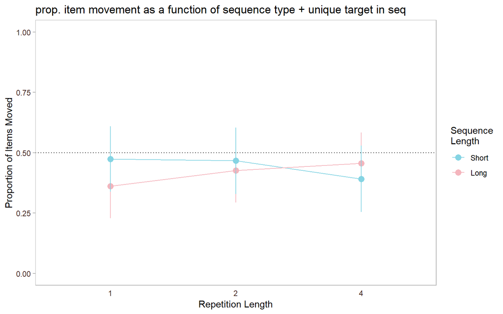

```r
graph1<-ddply(item2, .(SUBJECT, SeqType, Repetition), summarize,
              mean=mean(Move.Num)
              )

graph2<-ddply(graph1, .(SeqType, Repetition), summarize,
              dep.avg=mean(mean, na.rm=T),
              dep.sd=sd(mean, na.rm=T),
              dep.count=length(mean),
              dep.ci=dep.sd*qt(0.975,df=dep.count-1)/sqrt(dep.count))

graph2$Repetition=factor(graph2$Repetition)

ggplot(graph2, aes(x=Repetition, y=dep.avg, colour=SeqType, group=SeqType))+
  geom_point(size=3, shape=16, position = position_dodge(0))+
  geom_errorbar(aes(ymax=dep.avg+dep.ci,
                    ymin=dep.avg-dep.ci),
                    width=0, position = position_dodge(0))+
  geom_line()+
  theme(
    panel.background= element_rect(fill=NA), # transparent panel
    plot.background = element_rect(fill=NA, colour=NA), #transparent background
    panel.grid=element_blank(), # remove panel grid
    axis.ticks.x=element_blank(), # remove tick marks on x-axis
    axis.ticks=element_line(colour="gray70"), # change colour of tick marks
    panel.border = element_rect(fill="transparent", colour="gray70"), # change panel border colour
    legend.background = element_rect(fill = "transparent", colour = "transparent"), # change legend background
    axis.text = element_text(color="#432620"),
    legend.key = element_rect(fill = "transparent", colour = "transparent")
  )+
  ggtitle("prop. item movement as a function of sequence type + unique target in seq")+
  geom_hline(yintercept = 0.5, linetype="dotted")+
  scale_colour_manual("Sequence\nLength", values=wes_palette("Moonrise3", n=2))+
  scale_x_discrete("Repetition Length")+
  scale_y_continuous("Proportion of Items Moved", limits=c(0, 1))
```

```r
moves.mod<-glmer(Move.Num ~ SeqType*rep.c + (1 | SUBJECT), data = item2, family = binomial,
                  contrasts = list(SeqType="contr.sum"))
tab_model(moves.mod, transform = NULL, show.stat = T, p.val = "wald", digits.p = 2)
```

|  | Move Num |  |  |  |
| --- | --- | --- | --- | --- |
| Predictors | Log-Odds | CI | Statistic | p |
| (Intercept) | -0.57 | -1.32 – 0.17 | -1.50 | 0.13 |
| SeqType1 | 0.26 | 0.18 – 0.34 | 6.18 | **<0.001** |
| rep c | 0.03 | -0.05 – 0.11 | 0.81 | 0.42 |
| SeqType1:rep.c | -0.23 | -0.31 – -0.15 | -5.72 | **<0.001** |
| Random Effects |  |  |  |  |
| σ<sup>2</sup> | 3.29 |  |  |  |
| τ<sub>00</sub> <sub>SUBJECT</sub> | 4.30 |  |  |  |
| ICC | 0.57 |  |  |  |
| N <sub>SUBJECT</sub> | 30 |  |  |  |
| Observations | 5019 |  |  |  |
| Marginal R<sup>2</sup> / Conditional R<sup>2</sup> | 0.016 / 0.574 |  |  |  |

breaking down the two-way interaction

```r
# breaking down the two-way interaction
moves.mod2<-glmer(Move.Num ~ rep.c + (1 | SUBJECT), data = item2[item2$SeqType=="Short", ], family = binomial)
moves.mod3<-glmer(Move.Num ~ rep.c + (1 | SUBJECT), data = item2[item2$SeqType=="Long", ], family = binomial)

tab_model(moves.mod2, moves.mod3, transform = NULL, show.stat = T, p.val = "wald", digits.p = 2)
```

|  | Move Num |  |  |  | Move Num |  |  |  |
| --- | --- | --- | --- | --- | --- | --- | --- | --- |
| Predictors | Log-Odds | CI | Statistic | p | Log-Odds | CI | Statistic | p |
| (Intercept) | -0.38 | -1.17 – 0.40 | -0.96 | 0.34 | -0.84 | -1.62 – -0.06 | -2.12 | **0.03** |
| rep c | -0.20 | -0.33 – -0.07 | -3.05 | **<0.001** | 0.27 | 0.18 – 0.37 | 5.74 | **<0.001** |
| Random Effects |  |  |  |  |  |  |  |  |
| σ<sup>2</sup> | 3.29 |  |  |  | 3.29 |  |  |  |
| τ<sub>00</sub> | 4.62 <sub>SUBJECT</sub> |  |  |  | 4.58 <sub>SUBJECT</sub> |  |  |  |
| ICC | 0.58 |  |  |  | 0.58 |  |  |  |
| N | 30 <sub>SUBJECT</sub> |  |  |  | 30 <sub>SUBJECT</sub> |  |  |  |
| Observations | 1665 |  |  |  | 3354 |  |  |  |
| Marginal R<sup>2</sup> / Conditional R<sup>2</sup> | 0.005 / 0.586 |  |  |  | 0.010 / 0.586 |  |  |  |

Individuals are more likely to organize given items when they were presented among a short rather than long search sequence (b = .26, 95% CI [.18, .34], z = 6.18, p < .001).

However, this was qualified by a two-way interaction between sequence length and repetition (b = -.23, 95% CI [-.31, -.15], z = 5.72, p < .001). Specifically, for short sequence trials, individuals were less likely to organize their environments as repetition length increased (b = -.20, 95% CI [-.33, -.07], z = 3.05, p < .001). On the other hand, the likelihood of engaging in organization *increased* as repetition length increased when individuals encountered long search sequences (b = .27, 95% CI [.18, .37], z = 5.74, p < .001).

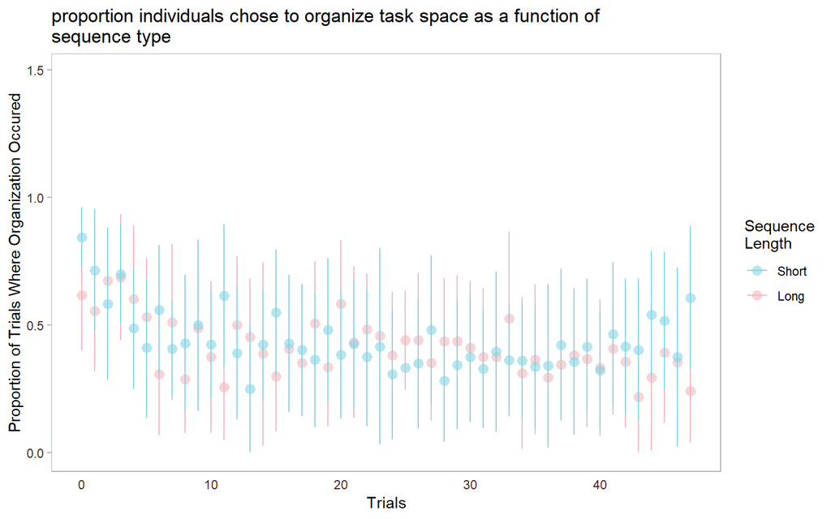

```r
graph1<-ddply(item2, .(SUBJECT, SeqType, TRIAL), summarize,
              mean=mean(Move.Num)
              )

graph2<-ddply(graph1, .(SeqType, TRIAL), summarize,
              dep.avg=mean(mean, na.rm=T),
              dep.sd=sd(mean, na.rm=T),
              dep.count=length(mean),
              dep.ci=dep.sd*qt(0.975,df=dep.count-1)/sqrt(dep.count))

ggplot(graph2, aes(x=TRIAL, y=dep.avg, colour=SeqType))+
  geom_point(size=3, shape=16, alpha = .6, position = position_dodge(0))+
  geom_errorbar(aes(ymax=dep.avg+dep.ci,
                    ymin=dep.avg-dep.ci),
                    width=0, position = position_dodge(0))+
  theme(
    panel.background= element_rect(fill=NA), # transparent panel
    plot.background = element_rect(fill=NA, colour=NA), #transparent background
    panel.grid=element_blank(), # remove panel grid
    axis.ticks.x=element_blank(), # remove tick marks on x-axis
    axis.ticks=element_line(colour="gray70"), # change colour of tick marks
    panel.border = element_rect(fill="transparent", colour="gray70"), # change panel border colour
    legend.background = element_rect(fill = "transparent", colour = "transparent"), # change legend background
    axis.text = element_text(color="#432620"),
    legend.key = element_rect(fill = "transparent", colour = "transparent")
  )+
  ggtitle("proportion individuals chose to organize task space as a function of \nsequence type")+
  # geom_vline(xintercept = 6, linetype="dotted")+
  scale_colour_manual("Sequence\nLength", values=wes_palette("Moonrise3", n=2))+
  scale_x_continuous("Trials")+
  scale_y_continuous("Proportion of Trials Where Organization Occured", limits=c(0, 1.49))
```

```r
moves.mod<-glmer(Move.Num ~ trial.c*SeqType*rep.c + (1 | SUBJECT), data = item2, family = binomial,
                  contrasts = list(SeqType="contr.sum"))
tab_model(moves.mod, transform = NULL, show.stat = T, p.val = "wald", digits.p = 2)
```

|  | Move Num |  |  |  |
| --- | --- | --- | --- | --- |
| Predictors | Log-Odds | CI | Statistic | p |
| (Intercept) | -0.59 | -1.36 – 0.18 | -1.51 | 0.13 |
| trial c | -0.03 | -0.04 – -0.03 | -10.14 | **<0.001** |
| SeqType1 | 0.27 | 0.18 – 0.35 | 6.24 | **<0.001** |
| rep c | 0.02 | -0.06 – 0.10 | 0.58 | 0.56 |
| trial.c:SeqType1 | 0.00 | -0.00 – 0.01 | 0.39 | 0.70 |
| trial.c:rep.c | 0.00 | -0.00 – 0.01 | 1.01 | 0.31 |
| SeqType1:rep.c | -0.25 | -0.33 – -0.17 | -5.97 | **<0.001** |
| trial.c:SeqType1:rep.c | 0.00 | -0.01 – 0.01 | 0.12 | 0.90 |
| Random Effects |  |  |  |  |
| σ<sup>2</sup> | 3.29 |  |  |  |
| τ<sub>00</sub> <sub>SUBJECT</sub> | 4.54 |  |  |  |
| ICC | 0.58 |  |  |  |
| N <sub>SUBJECT</sub> | 30 |  |  |  |
| Observations | 5019 |  |  |  |
| Marginal R<sup>2</sup> / Conditional R<sup>2</sup> | 0.040 / 0.597 |  |  |  |

When number of trials is added to the model, the only additional significant predictor is trial number itself (b = -.03, 95% CI [-.04, -.03], z = 10.14, p < .001)

No other additional main effects or interactions were significant (all p < .31).

#### Item Location

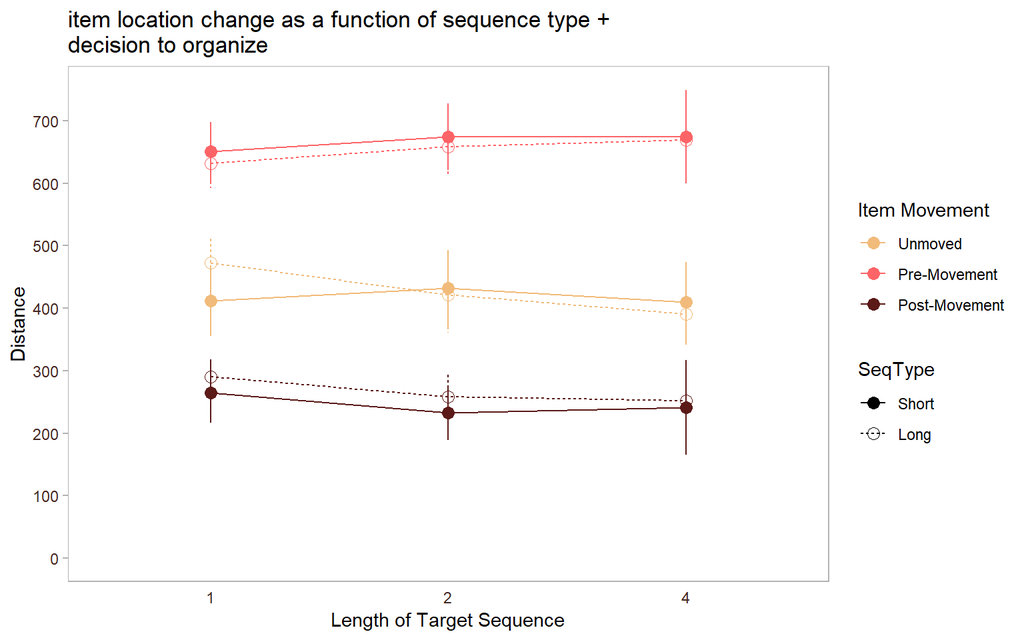

```r
# graph:
graph1<-ddply(item2.org, .(SUBJECT, Arrangement, SeqType, Repetition), summarize,
              mean=mean(Distance)
              )

graph2<-ddply(graph1, .(Arrangement, SeqType, Repetition), summarize,
              dep.avg=mean(mean, na.rm=T),
              dep.sd=sd(mean, na.rm=T),
              dep.count=length(mean),
              dep.ci=dep.sd*qt(0.975,df=dep.count-1)/sqrt(dep.count))

graph2$Repetition=factor(graph2$Repetition)

ggplot(graph2, aes(x=Repetition, y=dep.avg, shape=SeqType, linetype=SeqType, colour=Arrangement, group=interaction(Arrangement, SeqType)))+
  geom_point(size=3, position = position_dodge(0))+
  geom_errorbar(aes(ymax=dep.avg+dep.ci,
                    ymin=dep.avg-dep.ci),
                    width=0, position = position_dodge(0))+
  geom_line()+
  theme(
    panel.background= element_rect(fill=NA), # transparent panel
    plot.background = element_rect(fill=NA, colour=NA), #transparent background
    panel.grid=element_blank(), # remove panel grid
    axis.ticks.x=element_blank(), # remove tick marks on x-axis
    axis.ticks=element_line(colour="gray70"), # change colour of tick marks
    panel.border = element_rect(fill="transparent", colour="gray70"), # change panel border colour
    legend.background = element_rect(fill = "transparent", colour = "transparent"), # change legend background
    axis.text = element_text(color="#432620"),
    legend.key = element_rect(fill = "transparent", colour = "transparent")
  )+
  ggtitle("item location change as a function of sequence type + \ndecision to organize")+
  scale_shape_manual(values=c(16,1))+
  scale_colour_manual("Item Movement", values=wes_palette(n=3, name="GrandBudapest1"))+
  scale_x_discrete("Length of Target Sequence")+
  scale_y_continuous("Distance", limits=c(0, 750), breaks=seq(0, 1000, 100))
```

(pre- vs post-movement)

```r
item2.sub<-subset(item2.org, Arrangement!="Unmoved")
arr.mod<-lmer(Distance~SeqType*Arrangement*rep.c +(1|SUBJECT), data = item2.sub, REML=F, na.action="na.omit",
               contrasts = list(SeqType="contr.sum", Arrangement="contr.sum"))
tab_model(arr.mod, transform = NULL, show.stat = T, p.val = "wald", digits.p = 3)
```

|  | Distance |  |  |  |
| --- | --- | --- | --- | --- |
| Predictors | Estimates | CI | Statistic | p |
| (Intercept) | 452.70 | 432.17 – 473.24 | 43.21 | **<0.001** |
| SeqType1 | -9.34 | -14.81 – -3.86 | -3.34 | **0.001** |
| Arrangement1 | 199.46 | 194.07 – 204.84 | 72.59 | **<0.001** |
| rep c | -2.45 | -7.80 – 2.91 | -0.90 | 0.370 |
| SeqType1:Arrangement1 | 11.54 | 6.15 – 16.92 | 4.20 | **<0.001** |
| SeqType1:rep.c | 1.13 | -4.22 – 6.47 | 0.41 | 0.680 |
| Arrangement1:rep.c | 14.24 | 8.92 – 19.55 | 5.25 | **<0.001** |
| SeqType1:Arrangement1:rep.c | -5.37 | -10.68 – -0.05 | -1.98 | **0.048** |
| Random Effects |  |  |  |  |
| σ<sup>2</sup> | 28936.45 |  |  |  |
| τ<sub>00</sub> <sub>SUBJECT</sub> | 2678.23 |  |  |  |
| ICC | 0.08 |  |  |  |
| N <sub>SUBJECT</sub> | 30 |  |  |  |
| Observations | 4152 |  |  |  |
| Marginal R<sup>2</sup> / Conditional R<sup>2</sup> | 0.555 / 0.592 |  |  |  |

breaking down the 3 way interaction

```r
# breaking down the 3 way interaction
arr.mod2<-lmer(Distance~SeqType*rep.c +(1|SUBJECT), data = item2.sub[item2.sub$Arrangement=="Pre-Movement",],
              REML=F, na.action="na.omit", contrasts = list(SeqType="contr.sum"))
arr.mod3<-lmer(Distance~SeqType*rep.c +(1|SUBJECT), data = item2.sub[item2.sub$Arrangement=="Post-Movement",],
              REML=F, na.action="na.omit", contrasts = list(SeqType="contr.sum"))
tab_model(arr.mod2, arr.mod3, transform = NULL, show.stat = T, p.val = "wald", digits.p = 2)
```

|  | Distance |  |  |  | Distance |  |  |  |
| --- | --- | --- | --- | --- | --- | --- | --- | --- |
| Predictors | Estimates | CI | Statistic | p | Estimates | CI | Statistic | p |
| (Intercept) | 638.57 | 617.57 – 659.56 | 59.62 | **<0.001** | 269.39 | 238.53 – 300.26 | 17.11 | **<0.001** |
| SeqType1 | 2.82 | -7.05 – 12.69 | 0.56 | 0.58 | -21.79 | -26.06 – -17.51 | -9.99 | **<0.001** |
| rep c | 12.03 | 2.36 – 21.71 | 2.44 | **0.01** | -17.05 | -21.23 – -12.88 | -8.01 | **<0.001** |
| SeqType1:rep.c | -5.81 | -15.48 – 3.86 | -1.18 | 0.24 | 8.41 | 4.24 – 12.58 | 3.96 | **<0.001** |
| Random Effects |  |  |  |  |  |  |  |  |
| σ<sup>2</sup> | 47453.00 |  |  |  | 8773.72 |  |  |  |
| τ<sub>00</sub> | 2055.20 <sub>SUBJECT</sub> |  |  |  | 6934.69 <sub>SUBJECT</sub> |  |  |  |
| ICC | 0.04 |  |  |  | 0.44 |  |  |  |
| N | 30 <sub>SUBJECT</sub> |  |  |  | 30 <sub>SUBJECT</sub> |  |  |  |
| Observations | 2076 |  |  |  | 2076 |  |  |  |
| Marginal R<sup>2</sup> / Conditional R<sup>2</sup> | 0.005 / 0.046 |  |  |  | 0.054 / 0.471 |  |  |  |

breaking down the 2-way interaction for the post-movement condition

```r
# breaking down the 2-way interaction for the post-movement condition

arr.mod4<-lmer(Distance~rep.c +(1|SUBJECT), data = item2.sub[item2.sub$Arrangement=="Post-Movement" & item2.sub$SeqType=="Short",], REML=F, na.action="na.omit")
arr.mod5<-lmer(Distance~rep.c +(1|SUBJECT), data = item2.sub[item2.sub$Arrangement=="Post-Movement" & item2.sub$SeqType=="Long",], REML=F, na.action="na.omit")

tab_model(arr.mod4, arr.mod5, transform = NULL, show.stat = T, p.val = "wald", digits.p = 2)
```

|  | Distance |  |  |  | Distance |  |  |  |
| --- | --- | --- | --- | --- | --- | --- | --- | --- |
| Predictors | Estimates | CI | Statistic | p | Estimates | CI | Statistic | p |
| (Intercept) | 253.62 | 212.80 – 294.44 | 12.18 | **<0.001** | 276.69 | 253.77 – 299.60 | 23.67 | **<0.001** |
| rep c | -8.09 | -13.67 – -2.50 | -2.84 | **<0.001** | -24.66 | -29.87 – -19.45 | -9.28 | **<0.001** |
| Random Effects |  |  |  |  |  |  |  |  |
| σ<sup>2</sup> | 5798.99 |  |  |  | 10210.21 |  |  |  |
| τ<sub>00</sub> | 11926.57 <sub>SUBJECT</sub> |  |  |  | 3311.83 <sub>SUBJECT</sub> |  |  |  |
| ICC | 0.67 |  |  |  | 0.24 |  |  |  |
| N | 29 <sub>SUBJECT</sub> |  |  |  | 30 <sub>SUBJECT</sub> |  |  |  |
| Observations | 759 |  |  |  | 1317 |  |  |  |
| Marginal R<sup>2</sup> / Conditional R<sup>2</sup> | 0.004 / 0.674 |  |  |  | 0.049 / 0.282 |  |  |  |

Item distance was first examined only for target items that were later moved.

Item distance to the goal location was shorter for target items in short search sequences than long ones (b = -9.34, 95% CI [-14.81, -3.86], t = 3.34, p < .001).

Item distance pre-organization was further than post-organization (b = 199.46, 95% CI [194.07, 204.84], t = 72.59, p < .001).

There was a significant two-way interaction between organizational state (pre- vs post-movement) and sequence length (b = 11.54, 95% CI [6.15, 16.92], t = 4.20, p < .001), as well as a two-way interaction between organization state and repetition (b = 14.24, 95% CI [8.92, 19.55], t = 5.25, p < .001).

Importantly, there was a significant three way interaction (b = -5.37, 95% CI [-10.68, -.05], t = 1.98, p = .048). Prior to items being moved, item distance was positively related to repetition (b = 12.03, 95% CI [2.36, 21.71], t = 2.44, p = .01). However, post-organization, this relation was negative, such that item distance decreased as the number of repeated items in a sequence increased (b = -17.05, 95% CI [-21.23, -12.88], t = 8.01, p < .001). In addition, items in short sequences were placed closer to the goal location than in long ones (b = -21.79, 95% CI [-26.06, -17.51], t = 9.99, p < .001). These main effects were further qualified by a significant two-way interaction (b = 8.41, 95% CI [4.24, 12.58], t = 3.96, p < .001). Specifically, the negative association between item distance and repetition length was much stronger for items in the long (b = -24.66, 95% CI [-29.87, -19.45], t = 9.28, p < .001) rather than short search sequences (b = -8.09, 95% CI [-13.67, -2.50], t = 2.84, p < .001).

No other main effects or interactions were significant (all p > .37)

(unmoved vs pre-moved items)

```r
item2.sub<-subset(item2.org, Arrangement!="Post-Movement")
arr.mod<-lmer(Distance~SeqType*Arrangement*rep.c +(1|SUBJECT), data = item2.sub, REML=F, na.action="na.omit",
               contrasts = list(SeqType="contr.sum", Arrangement="contr.sum"))
tab_model(arr.mod, transform = NULL, show.stat = T, p.val = "wald", digits.p = 2)
```

|  | Distance |  |  |  |
| --- | --- | --- | --- | --- |
| Predictors | Estimates | CI | Statistic | p |
| (Intercept) | 567.53 | 545.80 – 589.25 | 51.20 | **<0.001** |
| SeqType1 | -3.47 | -10.22 – 3.28 | -1.01 | 0.31 |
| Arrangement1 | -96.58 | -105.27 – -87.88 | -21.77 | **<0.001** |
| rep c | -3.79 | -10.35 – 2.76 | -1.13 | 0.26 |
| SeqType1:Arrangement1 | -3.00 | -9.80 – 3.79 | -0.87 | 0.39 |
| SeqType1:rep.c | 0.56 | -6.00 – 7.13 | 0.17 | 0.87 |
| Arrangement1:rep.c | -14.12 | -20.70 – -7.54 | -4.20 | **<0.001** |
| SeqType1:Arrangement1:rep.c | 4.38 | -2.20 – 10.95 | 1.30 | 0.19 |
| Random Effects |  |  |  |  |
| σ<sup>2</sup> | 51265.14 |  |  |  |
| τ<sub>00</sub> <sub>SUBJECT</sub> | 3327.08 |  |  |  |
| ICC | 0.06 |  |  |  |
| N <sub>SUBJECT</sub> | 30 |  |  |  |
| Observations | 5019 |  |  |  |
| Marginal R<sup>2</sup> / Conditional R<sup>2</sup> | 0.143 / 0.196 |  |  |  |

arrangement * repetition

```r
# 2-way interaction between arrangement * repetition
arr.mod2<-lmer(Distance~rep.c +(1|SUBJECT), data = item2.sub[item2.sub$Arrangement=="Unmoved",],
              REML=F, na.action="na.omit")
arr.mod3<-lmer(Distance~rep.c +(1|SUBJECT), data = item2.sub[item2.sub$Arrangement=="Pre-Movement",],
              REML=F, na.action="na.omit")
tab_model(arr.mod2, arr.mod3, transform = NULL, show.stat = T, p.val = "wald", digits.p = 2)
```

|  | Distance |  |  |  | Distance |  |  |  |
| --- | --- | --- | --- | --- | --- | --- | --- | --- |
| Predictors | Estimates | CI | Statistic | p | Estimates | CI | Statistic | p |
| (Intercept) | 448.57 | 411.41 – 485.74 | 23.65 | **<0.001** | 638.49 | 617.70 – 659.28 | 60.19 | **<0.001** |
| rep c | -18.18 | -26.30 – -10.07 | -4.39 | **<0.001** | 13.82 | 4.76 – 22.88 | 2.99 | **<0.001** |
| Random Effects |  |  |  |  |  |  |  |  |
| σ<sup>2</sup> | 52197.69 |  |  |  | 47495.75 |  |  |  |
| τ<sub>00</sub> | 9822.52 <sub>SUBJECT</sub> |  |  |  | 2039.32 <sub>SUBJECT</sub> |  |  |  |
| ICC | 0.16 |  |  |  | 0.04 |  |  |  |
| N | 30 <sub>SUBJECT</sub> |  |  |  | 30 <sub>SUBJECT</sub> |  |  |  |
| Observations | 2943 |  |  |  | 2076 |  |  |  |
| Marginal R<sup>2</sup> / Conditional R<sup>2</sup> | 0.006 / 0.163 |  |  |  | 0.004 / 0.045 |  |  |  |

Unmoved items tended to be located closer to the goal location than items that were later moved (b = -96.58, 95% CI [-105.27, -87.88], t = 21.77, p < .001).

(unmoved vs. post-movement item distance)

```r
item2.sub<-subset(item2.org, Arrangement!="Pre-Movement")
arr.mod<-lmer(Distance~SeqType*Arrangement*rep.c +(1|SUBJECT), data = item2.sub, REML=F, na.action="na.omit",
               contrasts = list(SeqType="contr.sum", Arrangement="contr.sum"))
tab_model(arr.mod, transform = NULL, show.stat = T, p.val = "wald", digits.p = 2)
```

|  | Distance |  |  |  |
| --- | --- | --- | --- | --- |
| Predictors | Estimates | CI | Statistic | p |
| (Intercept) | 369.24 | 347.07 – 391.40 | 32.65 | **<0.001** |
| SeqType1 | -15.87 | -21.48 – -10.26 | -5.55 | **<0.001** |
| Arrangement1 | 94.17 | 86.87 – 101.48 | 25.28 | **<0.001** |
| rep c | -18.13 | -23.57 – -12.68 | -6.52 | **<0.001** |
| SeqType1:Arrangement1 | 9.27 | 3.63 – 14.92 | 3.22 | **<0.001** |
| SeqType1:rep.c | 6.78 | 1.32 – 12.23 | 2.44 | **0.01** |
| Arrangement1:rep.c | 0.04 | -5.42 – 5.51 | 0.02 | 0.99 |
| SeqType1:Arrangement1:rep.c | -2.61 | -8.07 – 2.86 | -0.93 | 0.35 |
| Random Effects |  |  |  |  |
| σ<sup>2</sup> | 35373.49 |  |  |  |
| τ<sub>00</sub> <sub>SUBJECT</sub> | 3588.38 |  |  |  |
| ICC | 0.09 |  |  |  |
| N <sub>SUBJECT</sub> | 30 |  |  |  |
| Observations | 5019 |  |  |  |
| Marginal R<sup>2</sup> / Conditional R<sup>2</sup> | 0.190 / 0.265 |  |  |  |

arrangement * seq length

```r
# 2-way interaction between arrangement * seq length
arr.mod2<-lmer(Distance~SeqType +(1|SUBJECT), data = item2.sub[item2.sub$Arrangement=="Unmoved",],
              REML=F, na.action="na.omit", contrasts = list(SeqType="contr.sum"))
arr.mod3<-lmer(Distance~SeqType +(1|SUBJECT), data = item2.sub[item2.sub$Arrangement=="Post-Movement",],
              REML=F, na.action="na.omit", contrasts = list(SeqType="contr.sum"))
tab_model(arr.mod2, arr.mod3, transform = NULL, show.stat = T, p.val = "wald", digits.p = 2)
```

|  | Distance |  |  |  | Distance |  |  |  |
| --- | --- | --- | --- | --- | --- | --- | --- | --- |
| Predictors | Estimates | CI | Statistic | p | Estimates | CI | Statistic | p |
| (Intercept) | 445.92 | 408.04 – 483.80 | 23.07 | **<0.001** | 266.41 | 236.69 – 296.13 | 17.57 | **<0.001** |
| SeqType1 | -6.96 | -16.00 – 2.07 | -1.51 | 0.13 | -20.07 | -24.45 – -15.69 | -8.99 | **<0.001** |
| Random Effects |  |  |  |  |  |  |  |  |
| σ<sup>2</sup> | 52486.98 |  |  |  | 9274.88 |  |  |  |
| τ<sub>00</sub> | 10128.92 <sub>SUBJECT</sub> |  |  |  | 6382.39 <sub>SUBJECT</sub> |  |  |  |
| ICC | 0.16 |  |  |  | 0.41 |  |  |  |
| N | 30 <sub>SUBJECT</sub> |  |  |  | 30 <sub>SUBJECT</sub> |  |  |  |
| Observations | 2943 |  |  |  | 2076 |  |  |  |
| Marginal R<sup>2</sup> / Conditional R<sup>2</sup> | 0.001 / 0.162 |  |  |  | 0.023 / 0.421 |  |  |  |

arrangement * repetition

```r
# 2-way interaction between arrangement * repetition
arr.mod4<-lmer(Distance~rep.c +(1|SUBJECT), data = item2.sub[item2.sub$Arrangement=="Unmoved",],
              REML=F, na.action="na.omit")
arr.mod5<-lmer(Distance~rep.c +(1|SUBJECT), data = item2.sub[item2.sub$Arrangement=="Post-Movement",],
              REML=F, na.action="na.omit")
tab_model(arr.mod4, arr.mod5, transform = NULL, show.stat = T, p.val = "wald", digits.p = 2)
```

|  | Distance |  |  |  | Distance |  |  |  |
| --- | --- | --- | --- | --- | --- | --- | --- | --- |
| Predictors | Estimates | CI | Statistic | p | Estimates | CI | Statistic | p |
| (Intercept) | 448.57 | 411.41 – 485.74 | 23.65 | **<0.001** | 272.37 | 242.18 – 302.56 | 17.68 | **<0.001** |
| rep c | -18.18 | -26.30 – -10.07 | -4.39 | **<0.001** | -18.27 | -22.29 – -14.25 | -8.91 | **<0.001** |
| Random Effects |  |  |  |  |  |  |  |  |
| σ<sup>2</sup> | 52197.69 |  |  |  | 9277.01 |  |  |  |
| τ<sub>00</sub> | 9822.52 <sub>SUBJECT</sub> |  |  |  | 6604.77 <sub>SUBJECT</sub> |  |  |  |
| ICC | 0.16 |  |  |  | 0.42 |  |  |  |
| N | 30 <sub>SUBJECT</sub> |  |  |  | 30 <sub>SUBJECT</sub> |  |  |  |
| Observations | 2943 |  |  |  | 2076 |  |  |  |
| Marginal R<sup>2</sup> / Conditional R<sup>2</sup> | 0.006 / 0.163 |  |  |  | 0.022 / 0.429 |  |  |  |

Target items in short search sequences tended to be placed closer to the goal location than in long sequences (b = -15.87, 95% CI [-21.48, -10.26], t = 5.55, p < .001).

Unmoved items tended to be located further from the goal location than item locations after they were moved (b = 94.17, 95% CI [86.87, 101.48], t = 25.28, p < .001).

There was an overall negative relation between item distance and repetition such that as the number of repeated items in a sequence increased, item distance decreased (b = -18.13, 95% CI [-23.57, -12.68], t = 6.52, p < .001).

There was a significant two-way interaction between sequence length and organizational state (unmoved vs. post-movement items; b = 9.27, 95% CI [3.63, 14.92], t = 3.22, p < .001). Item distance did not differ as a function of sequence length for unmoved items (b = -6.96, 95% CI [-16.00, 2.07], t = 1.51, p = .13). However, post-movement, items in a short sequence tended to be placed closer than items in a long sequence (b = -20.07, 95% CI [-24.45, -15.69], t = 8.99, p < .001).

# Combined Analysis

The following analyses examines comparable trials/conditions across experiments 1 & 2

```r
sub<-subset(df, SEQ_LEN %in% c(4,8) & NUM_UNIQUE_IN_SEQ %in% c(2,4))
sub$Experiment<-factor(recode(sub$Experiment, "'E1a'='E1';'E1b'='E1';'E2'='E2'"))
sub$uniq.c <- sub$NUM_UNIQUE_IN_SEQ - mean(sub$NUM_UNIQUE_IN_SEQ)
sub$rep.c<-sub$Repetition - mean(sub$Repetition)
sub$trial.c<-sub$TRIAL - mean(sub$TRIAL)

sub.org<-subset(df.org, SEQ_LEN %in% c(4,8) & NUM_UNIQUE_IN_SEQ %in% c(2,4))
sub.org$Experiment<-factor(recode(sub.org$Experiment, "'E1a'='E1';'E1b'='E1';'E2'='E2'"))
sub.org$uniq.c <- sub.org$NUM_UNIQUE_IN_SEQ - mean(sub.org$NUM_UNIQUE_IN_SEQ)
sub.org$rep.c<-sub.org$Repetition - mean(sub.org$Repetition)
sub.org$trial.c<-sub.org$TRIAL - mean(sub.org$TRIAL)

sub.item<-subset(item, SEQ_LEN %in% c(4,8) & NUM_UNIQUE_IN_SEQ %in% c(2,4))
sub.item$Experiment<-factor(recode(sub.item$Experiment, "'E1a'='E1';'E1b'='E1';'E2'='E2'"))
sub.item$uniq.c <- sub.item$NUM_UNIQUE_IN_SEQ - mean(sub.item$NUM_UNIQUE_IN_SEQ)
sub.item$rep.c<-sub.item$Repetition - mean(sub.item$Repetition)
sub.item$trial.c<-sub.item$TRIAL - mean(sub.item$TRIAL)

sub.item.org<-subset(item.org, SEQ_LEN %in% c(4,8) & NUM_UNIQUE_IN_SEQ %in% c(2,4))
sub.item.org$Experiment<-factor(recode(sub.item.org$Experiment, "'E1a'='E1';'E1b'='E1';'E2'='E2'"))
sub.item.org$uniq.c <- sub.item.org$NUM_UNIQUE_IN_SEQ - mean(sub.item.org$NUM_UNIQUE_IN_SEQ)
sub.item.org$rep.c<-sub.item.org$Repetition - mean(sub.item.org$Repetition)
sub.item.org$trial.c<-sub.item.org$TRIAL - mean(sub.item.org$TRIAL)
```

### Performance: Response Time

#### How much time did participants spent during the pre-search phase of the task?

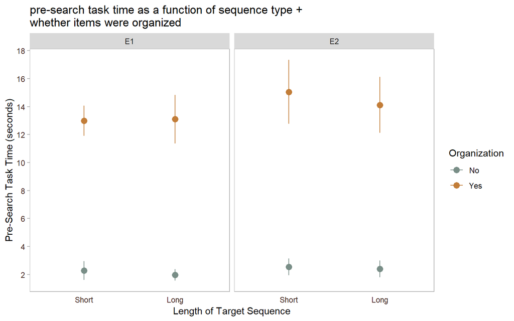

```r
graph1<-ddply(sub, .(SUBJECT, SeqType, Organization, Experiment), summarize,
              mean=mean(PrepTime)
              )

graph2<-ddply(graph1, .(SeqType, Organization, Experiment), summarize,
              dep.avg=mean(mean, na.rm=T),
              dep.sd=sd(mean, na.rm=T),
              dep.count=length(mean),
              dep.ci=dep.sd*qt(0.975,df=dep.count-1)/sqrt(dep.count))
# print(graph2)


ggplot(graph2, aes(x=SeqType, y=dep.avg, colour=Organization))+
  geom_point(size=3, shape=16, position = position_dodge(0))+
  geom_errorbar(aes(ymax=dep.avg+dep.ci,
                    ymin=dep.avg-dep.ci),
                    width=0, position = position_dodge(0))+
  facet_grid(.~Experiment)+
  theme(
    panel.background= element_rect(fill=NA), # transparent panel
    plot.background = element_rect(fill=NA, colour=NA), #transparent background
    panel.grid=element_blank(), # remove panel grid
    axis.ticks.x=element_blank(), # remove tick marks on x-axis
    axis.ticks=element_line(colour="gray70"), # change colour of tick marks
    panel.border = element_rect(fill="transparent", colour="gray70"), # change panel border colour
    legend.background = element_rect(fill = "transparent", colour = "transparent"), # change legend background
    axis.text = element_text(color="#432620"),
    legend.key = element_rect(fill = "transparent", colour = "transparent")
  )+
  ggtitle("pre-search task time as a function of sequence type + \nwhether items were organized")+
  scale_colour_manual(values=wes_palette(n=2, name="Moonrise2"))+
  scale_x_discrete("Length of Target Sequence")+
  scale_y_continuous("Pre-Search Task Time (seconds)", breaks=seq(0, 30, 2))
```

```r
pre.rt.mod<-lmer(PrepTime~SeqType*Organization*Experiment+(1|SUBJECT), data = sub, REML=F, na.action="na.omit",
                 contrasts=list(SeqType="contr.sum", Organization="contr.sum", Experiment="contr.sum"))
tab_model(pre.rt.mod, transform = NULL, show.stat = T, p.val = "wald", digits.p = 2)
```

|  | Prep Time |  |  |  |
| --- | --- | --- | --- | --- |
| Predictors | Estimates | CI | Statistic | p |
| (Intercept) | 7.73 | 7.26 – 8.19 | 32.55 | **<0.001** |
| SeqType1 | 0.07 | -0.24 – 0.39 | 0.47 | 0.64 |
| Organization1 | -5.71 | -6.08 – -5.34 | -30.44 | **<0.001** |
| Experiment1 | -0.27 | -0.74 – 0.19 | -1.14 | 0.25 |
| SeqType1:Organization1 | -0.10 | -0.42 – 0.21 | -0.65 | 0.51 |
| SeqType1:Experiment1 | -0.14 | -0.46 – 0.17 | -0.91 | 0.36 |
| Organization1:Experiment1 | 0.13 | -0.23 – 0.50 | 0.72 | 0.47 |
| SeqType1:Organization1:Experiment1 | 0.17 | -0.14 – 0.48 | 1.06 | 0.29 |
| Random Effects |  |  |  |  |
| σ<sup>2</sup> | 45.37 |  |  |  |
| τ<sub>00</sub> <sub>SUBJECT</sub> | 2.97 |  |  |  |
| ICC | 0.06 |  |  |  |
| N <sub>SUBJECT</sub> | 150 |  |  |  |
| Observations | 1973 |  |  |  |
| Marginal R<sup>2</sup> / Conditional R<sup>2</sup> | 0.399 / 0.436 |  |  |  |

Prep time was shorter for trials in which organization was not attempted than trials where individuals did organize their task space (b = -5.71, 95% CI [-6.08, -5.34], t = 30.44, p < .001)

No other main effects or interactions were significant (all p > .25).

#### Does average search time differ as a function of sequence type

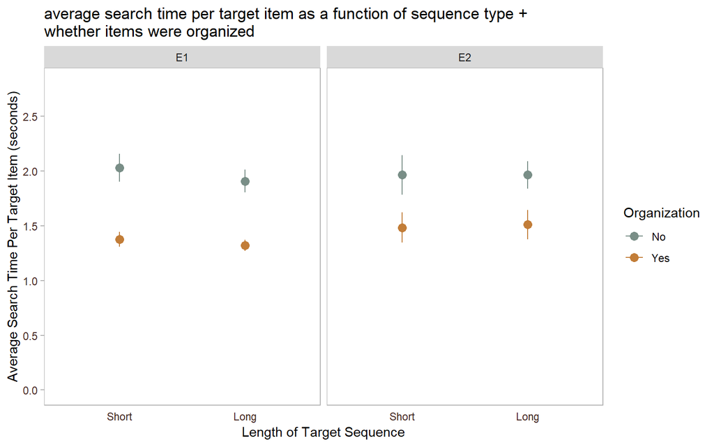

```r
graph1<-ddply(sub, .(SUBJECT, SeqType, Organization, Experiment), summarize,
              mean=mean(SearchTimeAvg)
              )

graph2<-ddply(graph1, .(SeqType, Organization, Experiment), summarize,
              dep.avg=mean(mean, na.rm=T),
              dep.sd=sd(mean, na.rm=T),
              dep.count=length(mean),
              dep.ci=dep.sd*qt(0.975,df=dep.count-1)/sqrt(dep.count))

ggplot(graph2, aes(x=SeqType, y=dep.avg, colour=Organization))+
  geom_point(size=3, shape=16, position = position_dodge(0))+
  geom_errorbar(aes(ymax=dep.avg+dep.ci,
                    ymin=dep.avg-dep.ci),
                    width=0, position = position_dodge(0))+
  facet_grid(.~Experiment)+
  theme(
    panel.background= element_rect(fill=NA), # transparent panel
    plot.background = element_rect(fill=NA, colour=NA), #transparent background
    panel.grid=element_blank(), # remove panel grid
    axis.ticks.x=element_blank(), # remove tick marks on x-axis
    axis.ticks=element_line(colour="gray70"), # change colour of tick marks
    panel.border = element_rect(fill="transparent", colour="gray70"), # change panel border colour
    legend.background = element_rect(fill = "transparent", colour = "transparent"), # change legend background
    axis.text = element_text(color="#432620"),
    legend.key = element_rect(fill = "transparent", colour = "transparent")
  )+
  ggtitle("average search time per target item as a function of sequence type + \nwhether items were organized")+
  scale_colour_manual(values=wes_palette(n=2, name="Moonrise2"))+
  scale_x_discrete("Length of Target Sequence")+
  scale_y_continuous("Average Search Time Per Target Item (seconds)", breaks=seq(0, 10, 0.5), limits=c(0, 2.8))
```

```r
post.rt.mod<-lmer(SearchTimeAvg~SeqType*Organization*Experiment + (1|SUBJECT), data = sub, REML=F, na.action="na.omit",
                  contrasts=list(SeqType="contr.sum", Organization="contr.sum", Experiment="contr.sum"))
tab_model(post.rt.mod, transform = NULL, show.stat = T, p.val = "wald", digits.p = 2)
```

|  | Search Time Avg |  |  |  |
| --- | --- | --- | --- | --- |
| Predictors | Estimates | CI | Statistic | p |
| (Intercept) | 1.66 | 1.60 – 1.71 | 62.56 | **<0.001** |
| SeqType1 | 0.03 | 0.01 – 0.05 | 3.19 | **<0.001** |
| Organization1 | 0.25 | 0.23 – 0.28 | 21.01 | **<0.001** |
| Experiment1 | -0.01 | -0.06 – 0.04 | -0.27 | 0.79 |
| SeqType1:Organization1 | 0.03 | 0.01 – 0.05 | 3.07 | **<0.001** |
| SeqType1:Experiment1 | 0.01 | -0.01 – 0.03 | 1.13 | 0.26 |
| Organization1:Experiment1 | 0.03 | 0.01 – 0.05 | 2.55 | **0.01** |
| SeqType1:Organization1:Experiment1 | -0.00 | -0.02 – 0.01 | -0.44 | 0.66 |
| Random Effects |  |  |  |  |
| σ<sup>2</sup> | 0.14 |  |  |  |
| τ<sub>00</sub> <sub>SUBJECT</sub> | 0.06 |  |  |  |
| ICC | 0.29 |  |  |  |
| N <sub>SUBJECT</sub> | 150 |  |  |  |
| Observations | 1973 |  |  |  |
| Marginal R<sup>2</sup> / Conditional R<sup>2</sup> | 0.256 / 0.475 |  |  |  |

seq length * organization:

```r
post.rt.mod2<-lmer(SearchTimeAvg~SeqType+ (1|SUBJECT), data = sub[sub$Organization=="No",], REML=F, na.action="na.omit",
                  contrasts=list(SeqType="contr.sum"))
post.rt.mod3<-lmer(SearchTimeAvg~SeqType+ (1|SUBJECT), data = sub[sub$Organization=="Yes",], REML=F, na.action="na.omit",
                  contrasts=list(SeqType="contr.sum"))
tab_model(post.rt.mod2, post.rt.mod3, transform = NULL, show.stat = T, p.val = "wald", digits.p = 2, digits = 3)
```

|  | Search Time Avg |  |  |  | Search Time Avg |  |  |  |
| --- | --- | --- | --- | --- | --- | --- | --- | --- |
| Predictors | Estimates | CI | Statistic | p | Estimates | CI | Statistic | p |
| (Intercept) | 1.973 | 1.903 – 2.043 | 55.343 | **<0.001** | 1.389 | 1.342 – 1.437 | 57.467 | **<0.001** |
| SeqType1 | 0.056 | 0.022 – 0.090 | 3.269 | **<0.001** | -0.004 | -0.020 – 0.012 | -0.474 | 0.64 |
| Random Effects |  |  |  |  |  |  |  |  |
| σ<sup>2</sup> | 0.22 |  |  |  | 0.06 |  |  |  |
| τ<sub>00</sub> | 0.09 <sub>SUBJECT</sub> |  |  |  | 0.06 <sub>SUBJECT</sub> |  |  |  |
| ICC | 0.29 |  |  |  | 0.50 |  |  |  |
| N | 115 <sub>SUBJECT</sub> |  |  |  | 135 <sub>SUBJECT</sub> |  |  |  |
| Observations | 857 |  |  |  | 1116 |  |  |  |
| Marginal R<sup>2</sup> / Conditional R<sup>2</sup> | 0.010 / 0.302 |  |  |  | 0.000 / 0.497 |  |  |  |

organization * experiment:

```r
post.rt.mod4<-lmer(SearchTimeAvg~Organization+ (1|SUBJECT), data = sub[sub$Experiment=="E1",], REML=F, na.action="na.omit",
                  contrasts=list(Organization="contr.sum"))
post.rt.mod5<-lmer(SearchTimeAvg~Organization+ (1|SUBJECT), data = sub[sub$Experiment=="E2",], REML=F, na.action="na.omit",
                  contrasts=list(Organization="contr.sum"))
tab_model(post.rt.mod4, post.rt.mod5, transform = NULL, show.stat = T, p.val = "wald", digits.p = 2)
```

|  | Search Time Avg |  |  |  | Search Time Avg |  |  |  |
| --- | --- | --- | --- | --- | --- | --- | --- | --- |
| Predictors | Estimates | CI | Statistic | p | Estimates | CI | Statistic | p |
| (Intercept) | 1.66 | 1.61 – 1.71 | 66.07 | **<0.001** | 1.66 | 1.57 – 1.75 | 35.92 | **<0.001** |
| Organization1 | 0.30 | 0.27 – 0.33 | 19.13 | **<0.001** | 0.22 | 0.19 – 0.26 | 12.37 | **<0.001** |
| Random Effects |  |  |  |  |  |  |  |  |
| σ<sup>2</sup> | 0.15 |  |  |  | 0.14 |  |  |  |
| τ<sub>00</sub> | 0.06 <sub>SUBJECT</sub> |  |  |  | 0.06 <sub>SUBJECT</sub> |  |  |  |
| ICC | 0.28 |  |  |  | 0.30 |  |  |  |
| N | 120 <sub>SUBJECT</sub> |  |  |  | 30 <sub>SUBJECT</sub> |  |  |  |
| Observations | 1020 |  |  |  | 953 |  |  |  |
| Marginal R<sup>2</sup> / Conditional R<sup>2</sup> | 0.301 / 0.495 |  |  |  | 0.196 / 0.435 |  |  |  |

Average search time per item is overall slower for items in short search squences than long ones (b = .03, 95% CI [.01, .05], t = 3.19, p < .001).

Individuals are slower to search for items when organization was not attempted than when organization was attempted (b = .25, 95% CI [.23, .28], t = 21.01, p < .001)

There was a significant two-way interaction between sequence length and whether organization was attempted (b = .03, 95% CI [.01, .05], t = 3.07, p < .001). When organization was not attempted, sequence length predicted average search time such that target items in short search sequences take longer to search for than items in long sequences (b = .06, 95% CI [.02, .09], t = 3.27, p < .001). However, sequence length did not significant predict search time for trials where organization was attempted (b = -.004, 95% CI [-.02. .01], t = .47, p = .64)

### Organizational Moves:

#### Did decision to organize (Y/N) change as a function of sequence type?

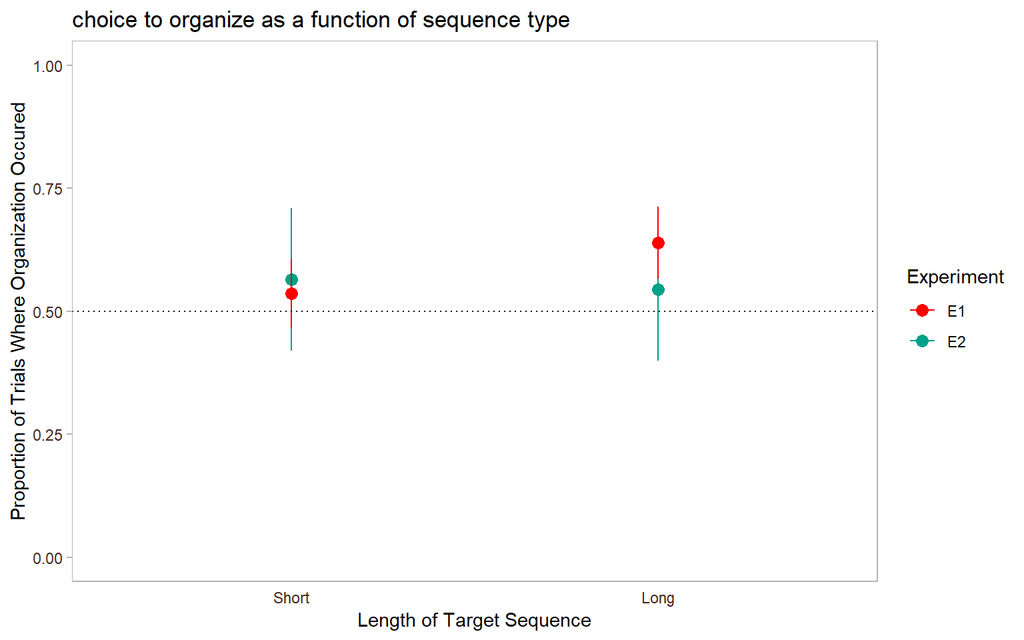

```r
graph1<-ddply(sub, .(SUBJECT, SeqType, Experiment), summarize,
              mean=mean(Org.Num)
              )

graph2<-ddply(graph1, .(SeqType, Experiment), summarize,
              dep.avg=mean(mean, na.rm=T),
              dep.sd=sd(mean, na.rm=T),
              dep.count=length(mean),
              dep.ci=dep.sd*qt(0.975,df=dep.count-1)/sqrt(dep.count))

ggplot(graph2, aes(x=SeqType, y=dep.avg, colour=Experiment))+
  geom_point(size=3, shape=16, position = position_dodge(0))+
  geom_errorbar(aes(ymax=dep.avg+dep.ci,
                    ymin=dep.avg-dep.ci),
                    width=0, position = position_dodge(0))+
  theme(
    panel.background= element_rect(fill=NA), # transparent panel
    plot.background = element_rect(fill=NA, colour=NA), #transparent background
    panel.grid=element_blank(), # remove panel grid
    axis.ticks.x=element_blank(), # remove tick marks on x-axis
    axis.ticks=element_line(colour="gray70"), # change colour of tick marks
    panel.border = element_rect(fill="transparent", colour="gray70"), # change panel border colour
    legend.background = element_rect(fill = "transparent", colour = "transparent"), # change legend background
    axis.text = element_text(color="#432620"),
    legend.key = element_rect(fill = "transparent", colour = "transparent")
  )+
  ggtitle("choice to organize as a function of sequence type")+
  geom_hline(yintercept = 0.5, linetype="dotted")+
  scale_colour_manual("Experiment", values=wes_palette("Darjeeling1", n=2))+
  scale_x_discrete("Length of Target Sequence")+
  scale_y_continuous("Proportion of Trials Where Organization Occured", limits=c(0, 1))
```

```r
moves.mod<-glmer(Org.Num ~ SeqType*Experiment + (1 | SUBJECT), data = sub, family = binomial,
                 contrasts = list(SeqType="contr.sum", Experiment="contr.sum"))
tab_model(moves.mod, transform = NULL, show.stat = T, p.val = "wald", digits.p = 2)
```

|  | Org Num |  |  |  |
| --- | --- | --- | --- | --- |
| Predictors | Log-Odds | CI | Statistic | p |
| (Intercept) | 0.67 | 0.14 – 1.19 | 2.49 | **0.01** |
| SeqType1 | -0.16 | -0.29 – -0.03 | -2.44 | **0.01** |
| Experiment1 | 0.04 | -0.48 – 0.57 | 0.16 | 0.87 |
| SeqType1:Experiment1 | -0.26 | -0.39 – -0.13 | -3.87 | **<0.001** |
| Random Effects |  |  |  |  |
| σ<sup>2</sup> | 3.29 |  |  |  |
| τ<sub>00</sub> <sub>SUBJECT</sub> | 6.18 |  |  |  |
| ICC | 0.65 |  |  |  |
| N <sub>SUBJECT</sub> | 150 |  |  |  |
| Observations | 1973 |  |  |  |
| Marginal R<sup>2</sup> / Conditional R<sup>2</sup> | 0.009 / 0.656 |  |  |  |

```r
moves.mod2<-glmer(Org.Num ~ SeqType + (1 | SUBJECT), data = sub[sub$Experiment=="E1",], family = binomial,
                 contrasts = list(SeqType="contr.sum"))
moves.mod3<-glmer(Org.Num ~ SeqType + (1 | SUBJECT), data = sub[sub$Experiment=="E2",], family = binomial,
                 contrasts = list(SeqType="contr.sum"))
tab_model(moves.mod2, moves.mod3, transform = NULL, show.stat = T, p.val = "wald", digits.p = 2)
```

|  | Org Num |  |  |  | Org Num |  |  |  |
| --- | --- | --- | --- | --- | --- | --- | --- | --- |
| Predictors | Log-Odds | CI | Statistic | p | Log-Odds | CI | Statistic | p |
| (Intercept) | 0.70 | 0.21 – 1.18 | 2.83 | **<0.001** | 0.64 | -0.33 – 1.62 | 1.29 | 0.20 |
| SeqType1 | -0.41 | -0.59 – -0.23 | -4.49 | **<0.001** | 0.10 | -0.09 – 0.28 | 1.00 | 0.32 |
| Random Effects |  |  |  |  |  |  |  |  |
| σ<sup>2</sup> | 3.29 |  |  |  | 3.29 |  |  |  |
| τ<sub>00</sub> | 5.87 <sub>SUBJECT</sub> |  |  |  | 6.88 <sub>SUBJECT</sub> |  |  |  |
| ICC | 0.64 |  |  |  | 0.68 |  |  |  |
| N | 120 <sub>SUBJECT</sub> |  |  |  | 30 <sub>SUBJECT</sub> |  |  |  |
| Observations | 1020 |  |  |  | 953 |  |  |  |
| Marginal R<sup>2</sup> / Conditional R<sup>2</sup> | 0.017 / 0.647 |  |  |  | 0.001 / 0.677 |  |  |  |

Overall, individuals are less likely to organize their task space when they encounter a short rather than long search sequence (b = -.16, 95% CI [-.29, -.03], z = 2.44, p = .01). This main effect is further qualified by a significant two-way interaction across experiments (b = -.26, 95% CI [-.39, -.13], z = 3.87, p < .001). Specifically, we found a significant effect of sequence length on likelihood to engage in organization in experiment 1 (b = -.41, 95% CI [-.59, -.23], z = 4.49, p < .001) but not for experiment 2 (b = .10, 95% CI [-.09 .28], z = 1.00, p = .32).

#### Decision to Organize (Y/N) as a function of sequence type across time

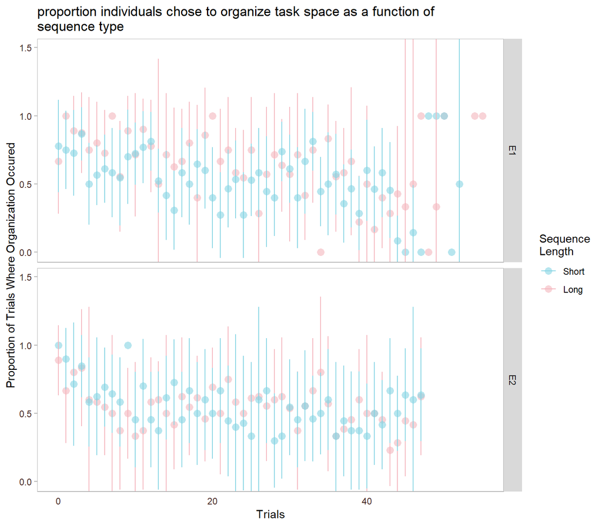

```r
graph1<-ddply(sub, .(SUBJECT, SeqType, TRIAL, Experiment), summarize,
              mean=mean(Org.Num)
              )

graph2<-ddply(graph1, .(SeqType, TRIAL, Experiment), summarize,
              dep.avg=mean(mean, na.rm=T),
              dep.sd=sd(mean, na.rm=T),
              dep.count=length(mean),
              dep.ci=dep.sd*qt(0.975,df=dep.count-1)/sqrt(dep.count))
ggplot(graph2, aes(x=TRIAL, y=dep.avg, colour=SeqType))+
  geom_point(size=3, shape=16, alpha = .6, position = position_dodge(0))+
  geom_errorbar(aes(ymax=dep.avg+dep.ci,
                    ymin=dep.avg-dep.ci),
                    width=0, position = position_dodge(0))+
  facet_grid(Experiment~.)+
  theme(
    panel.background= element_rect(fill=NA), # transparent panel
    plot.background = element_rect(fill=NA, colour=NA), #transparent background
    panel.grid=element_blank(), # remove panel grid
    axis.ticks.x=element_blank(), # remove tick marks on x-axis
    axis.ticks=element_line(colour="gray70"), # change colour of tick marks
    panel.border = element_rect(fill="transparent", colour="gray70"), # change panel border colour
    legend.background = element_rect(fill = "transparent", colour = "transparent"), # change legend background
    axis.text = element_text(color="#432620"),
    legend.key = element_rect(fill = "transparent", colour = "transparent")
  )+
  ggtitle("proportion individuals chose to organize task space as a function of \nsequence type")+
  scale_colour_manual("Sequence\nLength", values=wes_palette("Moonrise3", n=2))+
  scale_x_continuous("Trials")+
  scale_y_continuous("Proportion of Trials Where Organization Occured")+
  coord_cartesian(ylim = c(0, 1.49))
```

```r
moves.mod<-glmer(Org.Num ~ trial.c*SeqType*Experiment +(1|SUBJECT), data = sub, family = binomial(link = logit),
                 contrasts=list(SeqType="contr.sum", Experiment="contr.sum"), control=glmerControl(optimizer="bobyqa",
                            optCtrl=list(maxfun=2e5)))
tab_model(moves.mod, transform = NULL, show.stat = T, p.val = "wald", digits.p = 2)
```

|  | Org Num |  |  |  |
| --- | --- | --- | --- | --- |
| Predictors | Log-Odds | CI | Statistic | p |
| (Intercept) | 0.73 | 0.15 – 1.32 | 2.45 | **0.01** |
| trial c | -0.06 | -0.07 – -0.05 | -10.45 | **<0.001** |
| SeqType1 | -0.21 | -0.35 – -0.07 | -2.99 | **<0.001** |
| Experiment1 | 0.04 | -0.54 – 0.63 | 0.14 | 0.89 |
| trial.c:SeqType1 | -0.00 | -0.01 – 0.01 | -0.28 | 0.78 |
| trial.c:Experiment1 | -0.01 | -0.02 – 0.00 | -1.10 | 0.27 |
| SeqType1:Experiment1 | -0.31 | -0.45 – -0.17 | -4.37 | **<0.001** |
| trial.c:SeqType1:Experiment1 | 0.01 | -0.00 – 0.02 | 1.38 | 0.17 |
| Random Effects |  |  |  |  |
| σ<sup>2</sup> | 3.29 |  |  |  |
| τ<sub>00</sub> <sub>SUBJECT</sub> | 7.77 |  |  |  |
| ICC | 0.70 |  |  |  |
| N <sub>SUBJECT</sub> | 150 |  |  |  |
| Observations | 1973 |  |  |  |
| Marginal R<sup>2</sup> / Conditional R<sup>2</sup> | 0.065 / 0.722 |  |  |  |

**NOTE:** Optimizer was changed from Nelder_Mead to bobyqa in order to resolve convergence issue

As the number of trials increased, the likelihood of organization decreases (b = -.06, 95% CI [-.07, -.05], z = 10.45, p < .001).

Organization was less likely when participants encountered short rather than long search sequences (b = -.21, 95% CI [-.35, -.07] z = 2.99, p < .001). This was qualified by a two-way interaction between sequence length and experiment (b = -.31, 95% CI [-.45, -.17], z = 4.37, p < .001)

### Item Arrangement & Distance to Goal Location:

#### Did item location change pre- vs post-task as a function of sequence type?

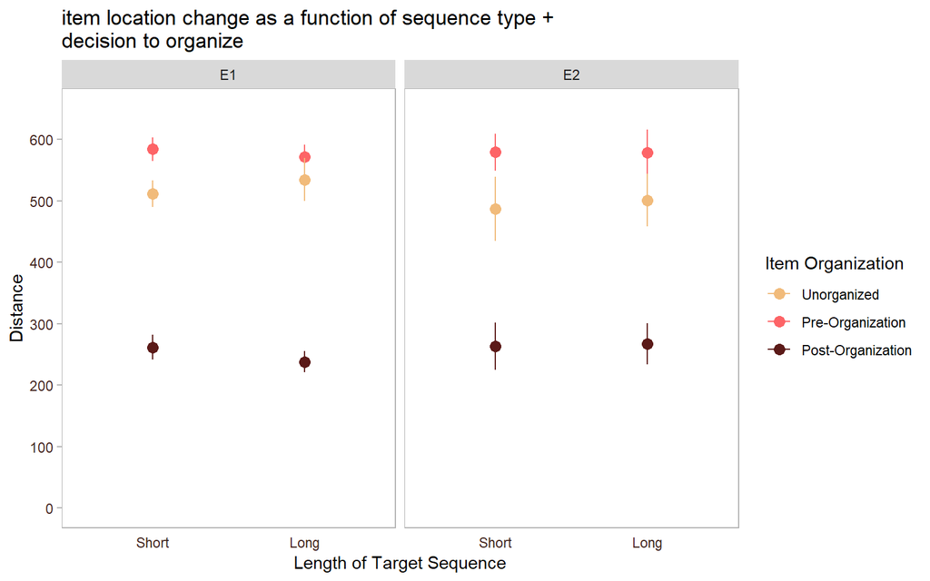

```r
graph1<-ddply(sub.org, .(SUBJECT, Arrangement, SeqType, Experiment), summarize,
              mean=mean(Distance)
              )

graph2<-ddply(graph1, .(Arrangement, SeqType, Experiment), summarize,
              dep.avg=mean(mean, na.rm=T),
              dep.sd=sd(mean, na.rm=T),
              dep.count=length(mean),
              dep.ci=dep.sd*qt(0.975,df=dep.count-1)/sqrt(dep.count))

ggplot(graph2, aes(x=SeqType, y=dep.avg, group=Arrangement, colour=Arrangement))+
  geom_point(size=3, shape=16, position = position_dodge(0))+
  geom_errorbar(aes(ymax=dep.avg+dep.ci,
                    ymin=dep.avg-dep.ci),
                    width=0, position = position_dodge(0))+
  facet_grid(.~Experiment)+
  theme(
    panel.background= element_rect(fill=NA), # transparent panel
    plot.background = element_rect(fill=NA, colour=NA), #transparent background
    panel.grid=element_blank(), # remove panel grid
    axis.ticks.x=element_blank(), # remove tick marks on x-axis
    axis.ticks=element_line(colour="gray70"), # change colour of tick marks
    panel.border = element_rect(fill="transparent", colour="gray70"), # change panel border colour
    legend.background = element_rect(fill = "transparent", colour = "transparent"), # change legend background
    axis.text = element_text(color="#432620"),
    legend.key = element_rect(fill = "transparent", colour = "transparent")
  )+
  ggtitle("item location change as a function of sequence type + \ndecision to organize")+
  scale_colour_manual("Item Organization", values=wes_palette(n=3, name="GrandBudapest1"))+
  scale_x_discrete("Length of Target Sequence")+
  scale_y_continuous("Distance", limits=c(0, 650), breaks=seq(0, 1000, 100))
```

(pre- vs post-organization)

```r
sub.org.sub<-subset(sub.org, Arrangement!="Unorganized")
arr.mod<-lmer(Distance~SeqType*Arrangement*Experiment +(1|SUBJECT), data = sub.org.sub, REML=F, na.action="na.omit",
              contrasts=list(SeqType="contr.sum", Arrangement="contr.sum", Experiment="contr.sum"))
tab_model(arr.mod, transform = NULL, show.stat = T, p.val = "wald", digits.p = 2)
```

|  | Distance |  |  |  |
| --- | --- | --- | --- | --- |
| Predictors | Estimates | CI | Statistic | p |
| (Intercept) | 415.11 | 405.09 – 425.13 | 81.17 | **<0.001** |
| SeqType1 | 0.74 | -4.48 – 5.95 | 0.28 | 0.78 |
| Arrangement1 | 173.92 | 168.84 – 179.01 | 67.05 | **<0.001** |
| Experiment1 | -3.09 | -13.11 – 6.93 | -0.60 | 0.55 |
| SeqType1:Arrangement1 | -1.51 | -6.60 – 3.57 | -0.58 | 0.56 |
| SeqType1:Experiment1 | 1.68 | -3.54 – 6.89 | 0.63 | 0.53 |
| Arrangement1:Experiment1 | -1.05 | -6.13 – 4.03 | -0.40 | 0.69 |
| SeqType1:Arrangement1:Experiment1 | -1.81 | -6.89 – 3.27 | -0.70 | 0.49 |
| Random Effects |  |  |  |  |
| σ<sup>2</sup> | 14738.43 |  |  |  |
| τ<sub>00</sub> <sub>SUBJECT</sub> | 1510.23 |  |  |  |
| ICC | 0.09 |  |  |  |
| N <sub>SUBJECT</sub> | 135 |  |  |  |
| Observations | 2232 |  |  |  |
| Marginal R<sup>2</sup> / Conditional R<sup>2</sup> | 0.650 / 0.682 |  |  |  |

There was only a main effect of organizational state (pre- vs post-organization; b = 173.92, 95% CI [168.84, 179.01], t = 67.05, p < .001).

No other main effects or interactions were significant (all p > .49).

(unorganized vs pre-organization)

```r
sub.org.sub<-subset(sub.org, Arrangement!="Post-Organization")
arr.mod<-lmer(Distance~SeqType*Arrangement*Experiment +(1|SUBJECT), data = sub.org.sub, REML=F, na.action="na.omit",
              contrasts=list(SeqType="contr.sum", Arrangement="contr.sum", Experiment="contr.sum"))
tab_model(arr.mod, transform = NULL, show.stat = T, p.val = "wald", digits.p = 2)
```

|  | Distance |  |  |  |
| --- | --- | --- | --- | --- |
| Predictors | Estimates | CI | Statistic | p |
| (Intercept) | 555.03 | 545.35 – 564.71 | 112.40 | **<0.001** |
| SeqType1 | 0.06 | -6.53 – 6.65 | 0.02 | 0.99 |
| Arrangement1 | -31.12 | -38.86 – -23.37 | -7.87 | **<0.001** |
| Experiment1 | 1.01 | -8.67 – 10.69 | 0.21 | 0.84 |
| SeqType1:Arrangement1 | 1.13 | -5.49 – 7.75 | 0.34 | 0.74 |
| SeqType1:Experiment1 | -5.33 | -11.92 – 1.26 | -1.58 | 0.11 |
| Arrangement1:Experiment1 | 4.73 | -3.02 – 12.48 | 1.20 | 0.23 |
| SeqType1:Arrangement1:Experiment1 | -4.95 | -11.56 – 1.67 | -1.47 | 0.14 |
| Random Effects |  |  |  |  |
| σ<sup>2</sup> | 20409.26 |  |  |  |
| τ<sub>00</sub> <sub>SUBJECT</sub> | 1247.18 |  |  |  |
| ICC | 0.06 |  |  |  |
| N <sub>SUBJECT</sub> | 150 |  |  |  |
| Observations | 1973 |  |  |  |
| Marginal R<sup>2</sup> / Conditional R<sup>2</sup> | 0.047 / 0.101 |  |  |  |

Only organizational state (unorganized vs pre-organization trials) led to differences in overall item distance (b = -31.12, 95% CI [-38.86, -23.37], t = 7.87, p < .001)

No other main effects or interactions were significant (all p > .11)

(unorganized vs post-organization)

```r
sub.org.sub<-subset(sub.org, Arrangement!="Pre-Organization")
arr.mod<-lmer(Distance~SeqType*Arrangement*Experiment +(1|SUBJECT), data = sub.org.sub, REML=F, na.action="na.omit",
              contrasts=list(SeqType="contr.sum", Arrangement="contr.sum", Experiment="contr.sum"))
tab_model(arr.mod, transform = NULL, show.stat = T, p.val = "wald", digits.p = 2)
```

|  | Distance |  |  |  |
| --- | --- | --- | --- | --- |
| Predictors | Estimates | CI | Statistic | p |
| (Intercept) | 379.11 | 367.68 – 390.54 | 65.01 | **<0.001** |
| SeqType1 | 1.96 | -3.35 – 7.26 | 0.72 | 0.47 |
| Arrangement1 | 126.14 | 119.30 – 132.97 | 36.18 | **<0.001** |
| Experiment1 | 2.93 | -8.50 – 14.36 | 0.50 | 0.62 |
| SeqType1:Arrangement1 | -0.52 | -5.86 – 4.82 | -0.19 | 0.85 |
| SeqType1:Experiment1 | -2.45 | -7.75 – 2.86 | -0.90 | 0.37 |
| Arrangement1:Experiment1 | 9.68 | 2.85 – 16.51 | 2.78 | **0.01** |
| SeqType1:Arrangement1:Experiment1 | -6.59 | -11.93 – -1.24 | -2.42 | **0.02** |
| Random Effects |  |  |  |  |
| σ<sup>2</sup> | 13019.37 |  |  |  |
| τ<sub>00</sub> <sub>SUBJECT</sub> | 2551.04 |  |  |  |
| ICC | 0.16 |  |  |  |
| N <sub>SUBJECT</sub> | 150 |  |  |  |
| Observations | 1973 |  |  |  |
| Marginal R<sup>2</sup> / Conditional R<sup>2</sup> | 0.500 / 0.582 |  |  |  |

breaking down the 3-way interaction

```r
arr.mod2<-lmer(Distance~SeqType*Arrangement +(1|SUBJECT), data = sub.org.sub[sub.org.sub$Experiment=="E1", ],
               REML=F, na.action="na.omit", contrasts=list(SeqType="contr.sum", Arrangement="contr.sum"))
arr.mod3<-lmer(Distance~SeqType*Arrangement +(1|SUBJECT), data = sub.org.sub[sub.org.sub$Experiment=="E2", ],
               REML=F, na.action="na.omit", contrasts=list(SeqType="contr.sum", Arrangement="contr.sum"))
tab_model(arr.mod2, arr.mod3, transform = NULL, show.stat = T, p.val = "wald", digits.p = 2)
```

|  | Distance |  |  |  | Distance |  |  |  |
| --- | --- | --- | --- | --- | --- | --- | --- | --- |
| Predictors | Estimates | CI | Statistic | p | Estimates | CI | Statistic | p |
| (Intercept) | 381.83 | 369.93 – 393.73 | 62.90 | **<0.001** | 376.22 | 356.26 – 396.18 | 36.94 | **<0.001** |
| SeqType1 | -0.35 | -7.73 – 7.03 | -0.09 | 0.93 | 4.42 | -3.17 – 12.00 | 1.14 | 0.25 |
| Arrangement1 | 134.74 | 126.02 – 143.46 | 30.29 | **<0.001** | 116.78 | 106.11 – 127.44 | 21.46 | **<0.001** |
| SeqType1:Arrangement1 | -7.13 | -14.58 – 0.31 | -1.88 | 0.06 | 6.07 | -1.56 – 13.69 | 1.56 | 0.12 |
| Random Effects |  |  |  |  |  |  |  |  |
| σ<sup>2</sup> | 11877.97 |  |  |  | 14116.95 |  |  |  |
| τ<sub>00</sub> | 2688.94 <sub>SUBJECT</sub> |  |  |  | 2655.68 <sub>SUBJECT</sub> |  |  |  |
| ICC | 0.18 |  |  |  | 0.16 |  |  |  |
| N | 120 <sub>SUBJECT</sub> |  |  |  | 30 <sub>SUBJECT</sub> |  |  |  |
| Observations | 1020 |  |  |  | 953 |  |  |  |
| Marginal R<sup>2</sup> / Conditional R<sup>2</sup> | 0.542 / 0.627 |  |  |  | 0.447 / 0.534 |  |  |  |

Item distance differed across rganizational states (unorganized vs post-organization; b = 126.14, 95% Ci [119.30, 132.97], t = 36.18, p < .001).

There was also a two-way interaction between oganizational state and experiment (b = 9.68, 95% CI [2.85, 16.51], t = 2.78, p = .01) as well as a significant three-way interaction (b = -6.59, 95% CI [-11.93, -1.24], t = 2.42, p = .02). Specifically, when split across experiments, the effect of organizational state on item distance was larger in experiment 1 (b = 134.74, 95% CI [126.02, 143.46], t = 30.29, p < .001) than in experiment 2 (b = 116.78, 95% CI [106.11, 127.44], t = 21.46, p < .001). However, no other main effects or interactions were significant across experiments.

No other main effects or interaction were significant (all p > .37).

## Item-Level Analyses

### Proportion of Items Moved

#### Did decision to move an item change as a function of sequence type?

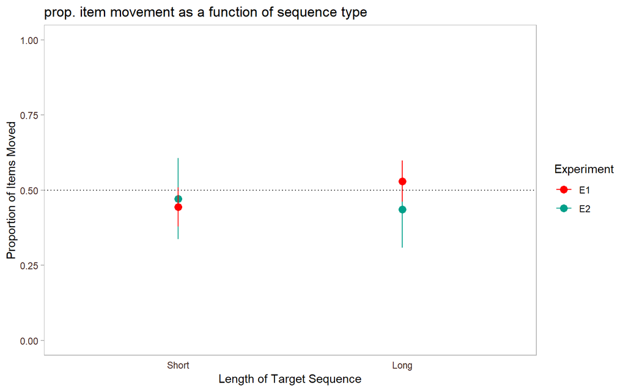

```r
graph1<-ddply(sub.item, .(SUBJECT, SeqType, Experiment), summarize,
              mean=mean(Move.Num)
              )

graph2<-ddply(graph1, .(SeqType, Experiment), summarize,
              dep.avg=mean(mean, na.rm=T),
              dep.sd=sd(mean, na.rm=T),
              dep.count=length(mean),
              dep.ci=dep.sd*qt(0.975,df=dep.count-1)/sqrt(dep.count))

ggplot(graph2, aes(x=SeqType, y=dep.avg, colour=Experiment))+
  geom_point(size=3, shape=16, position = position_dodge(0))+
  geom_errorbar(aes(ymax=dep.avg+dep.ci,
                    ymin=dep.avg-dep.ci),
                    width=0, position = position_dodge(0))+
  theme(
    panel.background= element_rect(fill=NA), # transparent panel
    plot.background = element_rect(fill=NA, colour=NA), #transparent background
    panel.grid=element_blank(), # remove panel grid
    axis.ticks.x=element_blank(), # remove tick marks on x-axis
    axis.ticks=element_line(colour="gray70"), # change colour of tick marks
    panel.border = element_rect(fill="transparent", colour="gray70"), # change panel border colour
    legend.background = element_rect(fill = "transparent", colour = "transparent"), # change legend background
    axis.text = element_text(color="#432620"),
    legend.key = element_rect(fill = "transparent", colour = "transparent")
  )+
  ggtitle("prop. item movement as a function of sequence type")+
  scale_colour_manual("Experiment", values=wes_palette("Darjeeling1", n=2))+
  geom_hline(yintercept = 0.5, linetype="dotted")+
  scale_x_discrete("Length of Target Sequence")+
  scale_y_continuous("Proportion of Items Moved", limits=c(0, 1))
```

```r
moves.mod<-glmer(Move.Num ~ SeqType*Experiment + (1 | SUBJECT), data = sub.item, family = binomial,
                 contrasts = list(SeqType="contr.sum", Experiment="contr.sum"))
tab_model(moves.mod, transform = NULL, show.stat = T, p.val = "wald", digits.p = 2)
```

|  | Move Num |  |  |  |
| --- | --- | --- | --- | --- |
| Predictors | Log-Odds | CI | Statistic | p |
| (Intercept) | -0.33 | -0.77 – 0.11 | -1.48 | 0.14 |
| SeqType1 | -0.09 | -0.16 – -0.02 | -2.46 | **0.01** |
| Experiment1 | 0.08 | -0.36 – 0.51 | 0.35 | 0.73 |
| SeqType1:Experiment1 | -0.22 | -0.29 – -0.15 | -6.05 | **<0.001** |
| Random Effects |  |  |  |  |
| σ<sup>2</sup> | 3.29 |  |  |  |
| τ<sub>00</sub> <sub>SUBJECT</sub> | 4.59 |  |  |  |
| ICC | 0.58 |  |  |  |
| N <sub>SUBJECT</sub> | 150 |  |  |  |
| Observations | 5934 |  |  |  |
| Marginal R<sup>2</sup> / Conditional R<sup>2</sup> | 0.007 / 0.585 |  |  |  |

two-way interaction:

```r
moves.mod2<-glmer(Move.Num ~ SeqType + (1 | SUBJECT), data = sub.item[sub.item$Experiment=="E1",], family = binomial,
                 contrasts = list(SeqType="contr.sum"))
moves.mod3<-glmer(Move.Num ~ SeqType + (1 | SUBJECT), data = sub.item[sub.item$Experiment=="E2",], family = binomial,
                 contrasts = list(SeqType="contr.sum"))
tab_model(moves.mod2, moves.mod3, transform = NULL, show.stat = T, p.val = "wald", digits.p = 2)
```

|  | Move Num |  |  |  | Move Num |  |  |  |
| --- | --- | --- | --- | --- | --- | --- | --- | --- |
| Predictors | Log-Odds | CI | Statistic | p | Log-Odds | CI | Statistic | p |
| (Intercept) | -0.26 | -0.67 – 0.16 | -1.22 | 0.22 | -0.40 | -1.13 – 0.32 | -1.09 | 0.28 |
| SeqType1 | -0.31 | -0.41 – -0.21 | -5.96 | **<0.001** | 0.13 | 0.03 – 0.23 | 2.57 | **0.01** |
| Random Effects |  |  |  |  |  |  |  |  |
| σ<sup>2</sup> | 3.29 |  |  |  | 3.29 |  |  |  |
| τ<sub>00</sub> | 4.81 <sub>SUBJECT</sub> |  |  |  | 4.00 <sub>SUBJECT</sub> |  |  |  |
| ICC | 0.59 |  |  |  | 0.55 |  |  |  |
| N | 120 <sub>SUBJECT</sub> |  |  |  | 30 <sub>SUBJECT</sub> |  |  |  |
| Observations | 3074 |  |  |  | 2860 |  |  |  |
| Marginal R<sup>2</sup> / Conditional R<sup>2</sup> | 0.011 / 0.598 |  |  |  | 0.002 / 0.550 |  |  |  |

Individuals are less likely to organize their task space when they encounter a short rather than long search sequence (b = -.09, 95% CI [-.16, -.02], z = 2.46, p = .01).

There was also a significant two-way interaction of sequence length across experiments (b = -.22, 95% CI [-.29, -.15], z = 6.05, p < .001). For experiment 1, short sequences are associated with a *decrease* in the likelihood that individuals will organize their environment (b = -.31, 95% CI [-.41, -.21], z = 5.96, p < .001). However, the opposite is true in experiment 2; individuals were more likely to organize their environments when presented with short rather than long sequences (b = .13, 95% CI [.03, .23], z = 2.57, p = .01)

#### Decision to move items as a function of sequence type over time

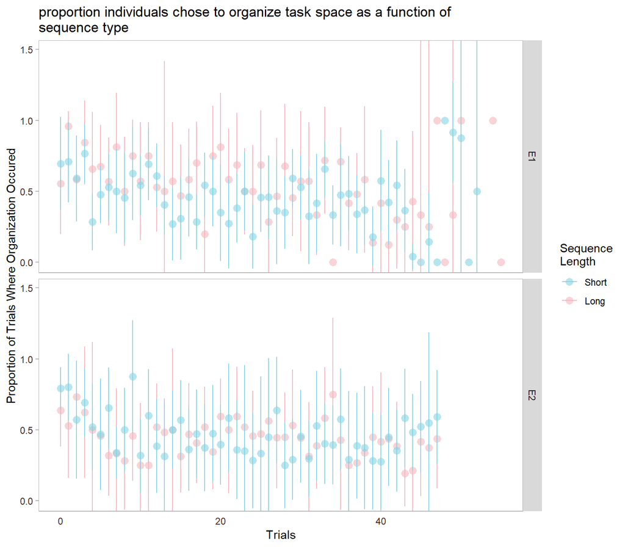

```r
graph1<-ddply(sub.item, .(SUBJECT, SeqType, TRIAL, Experiment), summarize,
              mean=mean(Move.Num)
              )

graph2<-ddply(graph1, .(SeqType, TRIAL, Experiment), summarize,
              dep.avg=mean(mean, na.rm=T),
              dep.sd=sd(mean, na.rm=T),
              dep.count=length(mean),
              dep.ci=dep.sd*qt(0.975,df=dep.count-1)/sqrt(dep.count))
ggplot(graph2, aes(x=TRIAL, y=dep.avg, colour=SeqType))+
  geom_point(size=3, shape=16, alpha = .6, position = position_dodge(0))+
  geom_errorbar(aes(ymax=dep.avg+dep.ci,
                    ymin=dep.avg-dep.ci),
                    width=0, position = position_dodge(0))+
  facet_grid(Experiment~.)+
  theme(
    panel.background= element_rect(fill=NA), # transparent panel
    plot.background = element_rect(fill=NA, colour=NA), #transparent background
    panel.grid=element_blank(), # remove panel grid
    axis.ticks.x=element_blank(), # remove tick marks on x-axis
    axis.ticks=element_line(colour="gray70"), # change colour of tick marks
    panel.border = element_rect(fill="transparent", colour="gray70"), # change panel border colour
    legend.background = element_rect(fill = "transparent", colour = "transparent"), # change legend background
    axis.text = element_text(color="#432620"),
    legend.key = element_rect(fill = "transparent", colour = "transparent")
  )+
  ggtitle("proportion individuals chose to organize task space as a function of \nsequence type")+
  scale_colour_manual("Sequence\nLength", values=wes_palette("Moonrise3", n=2))+
  scale_x_continuous("Trials")+
  scale_y_continuous("Proportion of Trials Where Organization Occured")+
  coord_cartesian(ylim=c(0, 1.49))
```

```r
moves.mod<-glmer(Move.Num ~ trial.c*SeqType*Experiment + (1 | SUBJECT), data = sub.item, family = binomial,
                  contrasts=list(SeqType="contr.sum", Experiment="contr.sum"))
tab_model(moves.mod, transform = NULL, show.stat = T, p.val = "wald", digits = 3, digits.p = 2)
```

|  | Move Num |  |  |  |
| --- | --- | --- | --- | --- |
| Predictors | Log-Odds | CI | Statistic | p |
| (Intercept) | -0.347 | -0.803 – 0.108 | -1.495 | 0.13 |
| trial c | -0.034 | -0.040 – -0.029 | -12.220 | **<0.001** |
| SeqType1 | -0.099 | -0.172 – -0.025 | -2.641 | **0.01** |
| Experiment1 | 0.062 | -0.394 – 0.517 | 0.265 | 0.79 |
| trial.c:SeqType1 | -0.003 | -0.008 – 0.002 | -1.113 | 0.27 |
| trial.c:Experiment1 | -0.007 | -0.013 – -0.002 | -2.668 | **0.01** |
| SeqType1:Experiment1 | -0.238 | -0.311 – -0.165 | -6.370 | **<0.001** |
| trial.c:SeqType1:Experiment1 | 0.002 | -0.003 – 0.007 | 0.759 | 0.45 |
| Random Effects |  |  |  |  |
| σ<sup>2</sup> | 3.29 |  |  |  |
| τ<sub>00</sub> <sub>SUBJECT</sub> | 4.98 |  |  |  |
| ICC | 0.60 |  |  |  |
| N <sub>SUBJECT</sub> | 150 |  |  |  |
| Observations | 5934 |  |  |  |
| Marginal R<sup>2</sup> / Conditional R<sup>2</sup> | 0.035 / 0.616 |  |  |  |

trial & seq length

```r
moves.mod2<-glmer(Move.Num ~ trial.c+ (1 | SUBJECT), data = sub.item[sub.item$Experiment=="E1", ],
                  family = binomial, contrasts=list(SeqType="contr.sum"))
moves.mod3<-glmer(Move.Num ~ trial.c+ (1 | SUBJECT), data = sub.item[sub.item$Experiment=="E2", ],
                  family = binomial, contrasts=list(SeqType="contr.sum"))
tab_model(moves.mod2, moves.mod3, transform = NULL, show.stat = T, p.val = "wald", digits.p = 2)
```

|  | Move Num |  |  |  | Move Num |  |  |  |
| --- | --- | --- | --- | --- | --- | --- | --- | --- |
| Predictors | Log-Odds | CI | Statistic | p | Log-Odds | CI | Statistic | p |
| (Intercept) | -0.38 | -0.81 – 0.04 | -1.78 | 0.08 | -0.40 | -1.15 – 0.34 | -1.06 | 0.29 |
| trial c | -0.04 | -0.05 – -0.03 | -10.45 | **<0.001** | -0.03 | -0.03 – -0.02 | -7.01 | **<0.001** |
| Random Effects |  |  |  |  |  |  |  |  |
| σ<sup>2</sup> | 3.29 |  |  |  | 3.29 |  |  |  |
| τ<sub>00</sub> | 5.06 <sub>SUBJECT</sub> |  |  |  | 4.19 <sub>SUBJECT</sub> |  |  |  |
| ICC | 0.61 |  |  |  | 0.56 |  |  |  |
| N | 120 <sub>SUBJECT</sub> |  |  |  | 30 <sub>SUBJECT</sub> |  |  |  |
| Observations | 3074 |  |  |  | 2860 |  |  |  |
| Marginal R<sup>2</sup> / Conditional R<sup>2</sup> | 0.035 / 0.620 |  |  |  | 0.018 / 0.568 |  |  |  |

Increased trial was associated with a decrease in the likelihood of organizing one’s environment (b = -.03, 95% CI [-.04, -.03], z = 12.22, p < .001).

Over and above the previous model, there was also a significant two-way interaction between trial and experiment (b = -.01 95% CI [-.013, -.002], z = 2.67, p = .01). Specifically, though there is a negative relation between trial and choice to organize the task space, this relation was stronger in experiment 1 (b = -.04, 95% CI [-.05, -.03], z = 10.45, p < .001) than in experiment 2 (b = -.03, 95% CI [-.03, -.02], z = 7.01, p < .001).

### Distance from target as a function of whether items were moved and sequence length

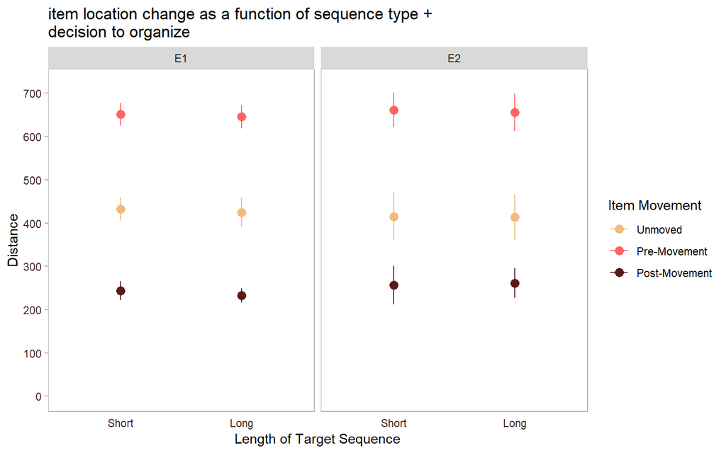

```r
graph1<-ddply(sub.item.org, .(SUBJECT, Arrangement, SeqType, Experiment), summarize,
              mean=mean(Distance)
              )

graph2<-ddply(graph1, .(Arrangement, SeqType, Experiment), summarize,
              dep.avg=mean(mean, na.rm=T),
              dep.sd=sd(mean, na.rm=T),
              dep.count=length(mean),
              dep.ci=dep.sd*qt(0.975,df=dep.count-1)/sqrt(dep.count))

ggplot(graph2, aes(x=SeqType, y=dep.avg, group=Arrangement, colour=Arrangement))+
  geom_point(size=3, shape=16, position = position_dodge(0))+
  geom_errorbar(aes(ymax=dep.avg+dep.ci,
                    ymin=dep.avg-dep.ci),
                    width=0, position = position_dodge(0))+
  facet_grid(.~Experiment)+
  theme(
    panel.background= element_rect(fill=NA), # transparent panel
    plot.background = element_rect(fill=NA, colour=NA), #transparent background
    panel.grid=element_blank(), # remove panel grid
    axis.ticks.x=element_blank(), # remove tick marks on x-axis
    axis.ticks=element_line(colour="gray70"), # change colour of tick marks
    panel.border = element_rect(fill="transparent", colour="gray70"), # change panel border colour
    legend.background = element_rect(fill = "transparent", colour = "transparent"), # change legend background
    axis.text = element_text(color="#432620"),
    legend.key = element_rect(fill = "transparent", colour = "transparent")
  )+
  ggtitle("item location change as a function of sequence type + \ndecision to organize")+
  scale_colour_manual("Item Movement", values=wes_palette(n=3, name="GrandBudapest1"))+
  scale_x_discrete("Length of Target Sequence")+
  scale_y_continuous("Distance", limits=c(0, 720), breaks=seq(0, 1000, 100))
```

(pre- vs post-movement)

```r
sub.item.org.sub<-subset(sub.item.org, Arrangement!="Unmoved")
arr.mod<-lmer(Distance~SeqType*Arrangement*Experiment +(1|SUBJECT), data = sub.item.org.sub, REML=F,
               na.action="na.omit", contrasts = list(SeqType="contr.sum", Arrangement="contr.sum",
                                                     Experiment="contr.sum"))
tab_model(arr.mod, transform = NULL, show.stat = T, p.val = "wald", digits.p = 2)
```

|  | Distance |  |  |  |
| --- | --- | --- | --- | --- |
| Predictors | Estimates | CI | Statistic | p |
| (Intercept) | 442.20 | 430.92 – 453.48 | 76.86 | **<0.001** |
| SeqType1 | -3.22 | -7.76 – 1.33 | -1.39 | 0.17 |
| Arrangement1 | 208.11 | 203.74 – 212.48 | 93.38 | **<0.001** |
| Experiment1 | -7.23 | -18.51 – 4.05 | -1.26 | 0.21 |
| SeqType1:Arrangement1 | -2.64 | -7.01 – 1.73 | -1.18 | 0.24 |
| SeqType1:Experiment1 | 1.84 | -2.70 – 6.39 | 0.79 | 0.43 |
| Arrangement1:Experiment1 | -1.91 | -6.28 – 2.46 | -0.86 | 0.39 |
| SeqType1:Arrangement1:Experiment1 | -0.70 | -5.07 – 3.67 | -0.31 | 0.75 |
| Random Effects |  |  |  |  |
| σ<sup>2</sup> | 26997.27 |  |  |  |
| τ<sub>00</sub> <sub>SUBJECT</sub> | 2196.75 |  |  |  |
| ICC | 0.08 |  |  |  |
| N <sub>SUBJECT</sub> | 134 |  |  |  |
| Observations | 5564 |  |  |  |
| Marginal R<sup>2</sup> / Conditional R<sup>2</sup> | 0.597 / 0.627 |  |  |  |

There was a main effect of organizational state (b = 208.11, 95% CI [203.74, 212.48], t = 93.38, p < .001) such that items prior to a move were located further away from the goal location than after an item was moved.

(unmoved vs pre-movement items)

```r
sub.item.org.sub<-subset(sub.item.org, Arrangement!="Post-Movement")
arr.mod<-lmer(Distance~SeqType*Arrangement*Experiment +(1|SUBJECT), data = sub.item.org.sub, REML=F,
               na.action="na.omit", contrasts = list(SeqType="contr.sum", Arrangement="contr.sum",
                                                     Experiment="contr.sum"))
tab_model(arr.mod, transform = NULL, show.stat = T, p.val = "wald", digits.p = 2)
```

|  | Distance |  |  |  |
| --- | --- | --- | --- | --- |
| Predictors | Estimates | CI | Statistic | p |
| (Intercept) | 564.89 | 550.44 – 579.33 | 76.65 | **<0.001** |
| SeqType1 | -0.29 | -6.22 – 5.65 | -0.09 | 0.92 |
| Arrangement1 | -102.07 | -109.34 – -94.81 | -27.53 | **<0.001** |
| Experiment1 | -3.22 | -17.67 – 11.22 | -0.44 | 0.66 |
| SeqType1:Arrangement1 | 5.24 | -0.69 – 11.17 | 1.73 | 0.08 |
| SeqType1:Experiment1 | 0.50 | -5.43 – 6.44 | 0.17 | 0.87 |
| Arrangement1:Experiment1 | 8.44 | 1.17 – 15.70 | 2.28 | **0.02** |
| SeqType1:Arrangement1:Experiment1 | -2.27 | -8.20 – 3.65 | -0.75 | 0.45 |
| Random Effects |  |  |  |  |
| σ<sup>2</sup> | 49479.13 |  |  |  |
| τ<sub>00</sub> <sub>SUBJECT</sub> | 4325.55 |  |  |  |
| ICC | 0.08 |  |  |  |
| N <sub>SUBJECT</sub> | 150 |  |  |  |
| Observations | 5934 |  |  |  |
| Marginal R<sup>2</sup> / Conditional R<sup>2</sup> | 0.161 / 0.228 |  |  |  |

```r
arr.mod2<-lmer(Distance~Arrangement +(1|SUBJECT), data = sub.item.org.sub[sub.item.org.sub$Experiment=="E1",],
               REML=F, na.action="na.omit", contrasts = list(Arrangement="contr.sum"))
arr.mod3<-lmer(Distance~Arrangement +(1|SUBJECT), data = sub.item.org.sub[sub.item.org.sub$Experiment=="E2",],
               REML=F, na.action="na.omit", contrasts = list(Arrangement="contr.sum"))
tab_model(arr.mod2, arr.mod3, transform = NULL, show.stat = T, p.val = "wald", digits.p = 2)
```

|  | Distance |  |  |  | Distance |  |  |  |
| --- | --- | --- | --- | --- | --- | --- | --- | --- |
| Predictors | Estimates | CI | Statistic | p | Estimates | CI | Statistic | p |
| (Intercept) | 561.95 | 547.80 – 576.09 | 77.86 | **<0.001** | 567.93 | 541.68 – 594.18 | 42.41 | **<0.001** |
| Arrangement1 | -92.56 | -101.95 – -83.17 | -19.32 | **<0.001** | -111.20 | -122.07 – -100.33 | -20.05 | **<0.001** |
| Random Effects |  |  |  |  |  |  |  |  |
| σ<sup>2</sup> | 48739.61 |  |  |  | 50328.38 |  |  |  |
| τ<sub>00</sub> | 4142.04 <sub>SUBJECT</sub> |  |  |  | 4842.51 <sub>SUBJECT</sub> |  |  |  |
| ICC | 0.08 |  |  |  | 0.09 |  |  |  |
| N | 120 <sub>SUBJECT</sub> |  |  |  | 30 <sub>SUBJECT</sub> |  |  |  |
| Observations | 3074 |  |  |  | 2860 |  |  |  |
| Marginal R<sup>2</sup> / Conditional R<sup>2</sup> | 0.139 / 0.207 |  |  |  | 0.182 / 0.254 |  |  |  |

Items that remain unmoved tended to be located closer to the goal location than the initial location of items that were later moved (b = -102.07, 95% CI [-109.34, -94.81], t = 27.53, p < .001)